Skip to contents

# 📉 CMSY++ catch-only stock assessment

Source: [`vignettes/articles/cmsy.Rmd`](https://github.com/Linbojun99/faofishingreport/blob/main/vignettes/articles/cmsy.Rmd)

CMSY++ (Froese et al. 2023), the successor of CMSY (Froese et al. 2017), estimates MSY, Bmsy and Fmsy, and the relative stock size (B/Bmsy) and exploitation (F/Fmsy) of every year, from a catch series, a prior for the intrinsic growth rate r and priors for the relative biomass B/k. The package bundles the official CMSY++ code (`CMSY++16.R`, January 2021), its neural network and its user guide (Froese et al. 2021), and a few functions take care of everything from installing JAGS (Plummer 2003) to drawing the charts. The CMSY++ runs shown in this article were made beforehand; building the article does not run CMSY++.

**FishStat has catches only, no CPUE.** The FAO capture statistics have no abundance index (CPUE or survey biomass), so every stock is assessed with the catch-only part of CMSY++ (CMSY, `btype = "None"`) and the Bayesian Schaefer model (BSM) does not run. The results then depend mostly on the B/k priors, and independent tests found that catch-only methods classify stock status poorly with default priors (Free et al. 2020; Ovando et al. 2021; Kell et al. 2022). The results are **indicative** and do not replace stock assessments. As in FAO (2026), the status has two classes only: **maximally sustainably fished** (B/Bmsy at least 0.8 in the last year) or **overfished** (below 0.8); catch-only results do not make a stock “underfished”.

**Disclaimer and source of CMSY++.** CMSY++ was developed by Rainer Froese and colleagues (Froese et al. 2021, 2023). faofishingreport is not affiliated with or endorsed by the authors of CMSY++. The package bundles the authors’ unmodified March 2021 release (GEOMAR OceanRep, record [52147](https://oceanrep.geomar.de/id/eprint/52147/), CC BY 4.0), whose code is also published on GitHub at https://github.com/SISTA16/cmsyPlusPlus. `cmsy_run()` runs a copy of it with only the changes listed in `code_changes.csv` of each run folder (operating-system settings, no automatic package installation), which leave the method unchanged. Questions on the method go to the authors of CMSY++; problems with how this package runs it go to the [faofishingreport issues](https://github.com/Linbojun99/faofishingreport/issues). Users are responsible for checking and interpreting the results.

## ⚙️ Common arguments

These arguments have the same meaning in all CMSY functions that have them; the tables of each function below list its other arguments.

| Argument | Meaning | Default |
| --- | --- | --- |
| `stocks` | Stocks to use: `Stock` identifiers (e.g. `"PRA_27"`) or species, by English or Chinese FAO name, scientific name or FAO 3-alpha code (all stocks of the species) | `NULL`: all stocks |
| `table` | Save the tables (in `tables/cmsy/`) | `TRUE` |
| `lang` | Language of the chart text, names and table columns: `"en"`, `"zh"` or `"both"` | `NULL`: the language of `fao_settings()` (`"en"` unless changed) |
| `pptx` | Also save the charts as editable PowerPoint files (in `figures/pptx/cmsy/`) | `FALSE`; `fao_settings(pptx = TRUE)` changes it for all functions |
| `plot_show` | Also draw each chart in the plot window (e.g. the Plots pane of RStudio) as it is saved | `FALSE`, or `plot_show` of `fao_settings()` |
| `annotations` | Text added to the axis titles and labels: `FALSE` none, `TRUE` all, or any of `"title"`, `"subtitle"`, `"caption"`, `"legend"` and `"labels"` (text inside the chart) | `FALSE`; `options(faofishingreport.cmsy_annotations = TRUE)` changes it for the session |
| `silent` | Print no progress bars and messages | `FALSE`; `fao_settings(silent = TRUE)` changes it for the session |
| `data_dir` | Folder where downloads are kept | `fao_data_dir()` |

## 🚀 One step: cmsy_area()

```r
cmsy_setup()                                                     # once: JAGS and the R packages
area27 <- cmsy_area("Atlantic, Northeast", top = 10)
```

`cmsy_area()` does Steps 4 to 7 and Step 9 below in one call: it takes the `top` species with the largest catch of the last `recent_years` years of a fishing area (or the species given in `species`), prepares the input, runs CMSY++, draws all charts, projects the stocks and writes the tables, with a progress bar for each step. Main species that cannot be assessed (e.g. without an r prior) are listed with the reason. `area` can name several areas; each gets its own folder in `out_dir`, sorted into:

```
cmsy_areas/Atlantic__Eastern_Central/
├── input/      CMSY++ catch and ID files (catch.csv, id.csv), the stocks assessed (stocks.csv)
│               and the main species left out with the reason (excluded.csv)
├── runs/       CMSY++ output of each stock (JPEG charts, cmsy_output.csv, log.txt), the changed
│               code and the list of changes (code_changes.csv)
├── figures/    a folder of charts per stock and summary/ (figures_pptx/ with pptx = TRUE)
└── tables/     results.csv, series.csv, priors_table.csv, results_table.csv, forecast.csv,
                forecast_share.csv, settings_used.csv and sources.csv
```

| Argument | Meaning | Default |
| --- | --- | --- |
| `area` | FAO major fishing area name(s), as in `fishing_area_data()` (e.g. `"Atlantic, Eastern Central"`), or FAO catch data such as `fishing_area_data()$area_data` | required |
| `top` | Number of species with the largest catch to assess | `10` |
| `species` | Species to assess instead of the `top` ones: English or Chinese name, scientific name or FAO 3-alpha code | `NULL` |
| `recent_years` | Species are ranked by their mean catch over the last `recent_years` years of the data | `10` |
| `out_dir` | Folder in which a folder per area is made | `"cmsy_areas"` |
| `auto_start` | Start a stock in the year suggested by CMSY++ when its start biomass is ambiguous (see Step 5) | `TRUE` (`FALSE` in `cmsy_run()`) |
| `seed` | Random seed, so runs can be repeated with the same results | `1` |
| `parallel` | Number of stocks run at the same time; each uses two more processes for its two MCMC chains | `NULL`: half the processor cores |
| `settings` | CMSY++ settings that replace its defaults (see The settings of CMSY++) | `list()`: none |
| `charts` | Charts to draw (see Step 6) | all charts |
| `classes` | Status classes: `"fao"` (two) or `"palomares"` (five) | `"fao"` |
| `forecast` | Also project the stocks under the default scenarios of `cmsy_forecast()` | `TRUE` |
| `annotations`, `lang`, `pptx`, `silent` | See Common arguments |  |
| `...` | Further arguments of `cmsy_input()`, e.g. `priors`, `default_resilience` or `min_years` |  |

`cmsy_area()` runs CMSY++ without the retrospective analysis, so its retrospective chart is skipped (see Step 5). It returns the result of `cmsy_run()` with `input`, `forecast`, `tables` and `dir` (the folder of the area); for several areas, a list of these named by area. On a Mac with Apple silicon, the ten main species of area 27 take about a minute from input to tables.

## 💻 Step 1: check the computer and adapt the settings

The CMSY++ code was written on Windows. Its user guide (step 12) tells Mac users to change every `windows()` to `quartz()` and `antialias = "cleartype"` to `"default"`. The code tests for Windows with `grepl("win", sysname)`, which is also true for macOS (“Darwin”), so on a Mac it calls `windows()` and stops. `cmsy_system()` finds the operating system, R version, processor, JAGS and R packages, and shows the settings `cmsy_run()` will use:

```r
sys <- cmsy_system()
show_table(sys$changes)
```

| change | applies_to | what |
| --- | --- | --- |
| Package installation | all | Lines that install missing packages on every run are removed (cmsy_setup() installs them). |
| snpar | all | library(snpar) is removed and snpar::runs.test() is replaced by the same approximate runs test, reproduced from snpar 1.0 (Debin Qiu, GPL >= 2; archived on CRAN on 2022-05-10: https://cran.r-project.o… |
| Working directory | all | setwd(rstudioapi::getActiveDocumentContext()$path) is removed, so RStudio is not needed; each stock runs in its own folder. |
| Settings | all | File names, the stock, the chart switches and the general settings (CMSY++ defaults unless changed with cmsy_run(settings = ), including the MCMC iterations of the JAGS call) are set by cmsy_run() aft… |
| Chart windows | linux | The test grepl(“win”, sysname), which is also true on macOS (“Darwin”), is replaced; windows(): changed to an off-screen device, so charts are drawn and saved without opening windows. |
| JPEG antialias | linux | antialias = “cleartype” (Windows only) is changed to “default” (user guide, step 12). |
| Results for charts | all | After the main analysis of a stock, its priors, the posterior draws of r, k and B/k, the yearly estimates with 95% limits and the last-year Kobe draws are saved to cmsy_extra.rds (retrospective runs t… |

The changes are made to a copy of the code written into each run folder (`CMSY++16_faofishingreport.R`, with the list in `code_changes.csv`); the bundled original never changes. Charts are drawn on an off-screen device by default, which saves the JPEG files on every system without opening windows; `device = "screen"` uses the system’s own window instead (`windows()`, `quartz()` or `x11()`). If the detection is wrong, set the system:

```r
cmsy_system(os = "windows")                       # settings used on Windows
options(faofishingreport.cmsy_os = "macos")       # for the whole session
```

| Argument | Meaning | Default |
| --- | --- | --- |
| `os` | Operating system whose settings are used: `"auto"` (detect it), `"windows"`, `"macos"` or `"linux"` | `"auto"` |
| `device` | Where CMSY++ draws its charts before saving them as JPEG files: `"file"` (an off-screen device that works on every system and in batch runs) or `"screen"` (the system’s own window) | `"file"` |
| `jags` | JAGS version to recommend: `"recommended"` (the newest JAGS 4 for this R version, which works with rjags from CRAN), `"latest"` (JAGS 5.0.0, which needs rjags 5 from SourceForge) or a version number s… | `"recommended"` |
| `silent` | See Common arguments |  |

It returns the system (`os`, `os_detected`, `arch`, `r_version`), the installed `jags` and `rjags` versions, the `packages` table, the recommended `jags_installer` and `rjags_source`, the chart `device` and `antialias`, and the `changes` made to the CMSY++ code.

## 🧰 Step 2: install JAGS and the R packages

```r
cmsy_setup()
```

`cmsy_setup()` asks before installing anything, then:

1. installs the missing R packages from CRAN (R2jags, rjags, coda, gplots, mvtnorm, neuralnet, conicfit); snpar, archived on CRAN on 2022-05-10, is replaced by the same approximate runs test, reproduced from snpar 1.0 (Debin Qiu, GPL ≥ 2; [CRAN archive](https://cran.r-project.org/src/contrib/Archive/snpar/), source mirror https://github.com/cran/snpar);
2. downloads the JAGS installer for the system and R version from its pinned link, checks its size and MD5 checksum and opens it (`.exe` on Windows, `.pkg` on macOS; on Linux it downloads the source and shows the commands). JAGS is a separate program: restart R after installing it and run `cmsy_setup()` again to check;
3. checks the bundled CMSY++ files.

| Argument | Meaning | Default |
| --- | --- | --- |
| `jags` | JAGS version: `"recommended"`, `"latest"` or a version number (as in `cmsy_system()`) | `"recommended"` |
| `os` | Operating system: `"auto"`, `"windows"`, `"macos"` or `"linux"` | `"auto"` |
| `ask` | Ask before installing anything; in a non-interactive session nothing is installed when `ask` is `TRUE` | `TRUE` |
| `data_dir`, `silent` | See Common arguments |  |

It returns the result of `cmsy_system()` after the installation. JAGS 4.3.2 (4.3.1 for older R versions) is the default because rjags on CRAN (4-17) needs JAGS 4. The newest JAGS, 5.0.0, needs rjags 5-3 from SourceForge: `cmsy_setup(jags = "latest")`. Installers copied into `inst/jags/` of the package source are used instead of downloading. Versions, links, sizes, checksums, licences and references of every component are listed by `cmsy_sources()`:

```r
src <- cmsy_sources()
show_table(src[, c("component", "version", "platform", "file", "license", "url")], n = 30)
```

| component | version | platform | file | license | url |
| --- | --- | --- | --- | --- | --- |
| CMSY++ code | 16 (January 2021) | all | CMSY++16.R | CC BY 4.0 | https://oceanrep.geomar.de/id/eprint/52147/4/UserGuideCodeDataMarch2021.zip |
| CMSY++ neural network | 16 (January 2021) | all | ffnn.bin | CC BY 4.0 | https://oceanrep.geomar.de/id/eprint/52147/4/UserGuideCodeDataMarch2021.zip |
| CMSY++ user guide | March 2021 | all | CMSYUserGuideMarch2021.pdf | CC BY 4.0 | https://oceanrep.geomar.de/id/eprint/52147/4/UserGuideCodeDataMarch2021.zip |
| CMSY++ training data (catch) | 9e | all | Train_Catch_9e.csv | CC BY 4.0 | https://oceanrep.geomar.de/id/eprint/52147/4/UserGuideCodeDataMarch2021.zip |
| CMSY++ training data (stocks) | 9e | all | Train_ID_9e.csv | CC BY 4.0 | https://oceanrep.geomar.de/id/eprint/52147/4/UserGuideCodeDataMarch2021.zip |
| JAGS | 4.3.2 | windows | JAGS-4.3.2.exe | GPL-2 | https://downloads.sourceforge.net/project/mcmc-jags/JAGS/4.x/Windows/JAGS-4.3.2.exe |
| JAGS | 4.3.1 | windows | JAGS-4.3.1.exe | GPL-2 | https://downloads.sourceforge.net/project/mcmc-jags/JAGS/4.x/Windows/JAGS-4.3.1.exe |
| JAGS | 4.3.2 | macos | JAGS-4.3.2.pkg | GPL-2 | https://downloads.sourceforge.net/project/mcmc-jags/JAGS/4.x/Mac%20OS%20X/JAGS-4.3.2.pkg |
| JAGS | 4.3.1 | macos | JAGS-4.3.1.pkg | GPL-2 | https://downloads.sourceforge.net/project/mcmc-jags/JAGS/4.x/Mac%20OS%20X/JAGS-4.3.1.pkg |
| JAGS | 4.3.2 | source | JAGS-4.3.2.tar.gz | GPL-2 | https://downloads.sourceforge.net/project/mcmc-jags/JAGS/4.x/Source/JAGS-4.3.2.tar.gz |
| JAGS | 5.0.0 | windows | JAGS-5.0.0.exe | GPL-2 | https://downloads.sourceforge.net/project/mcmc-jags/JAGS/5.x/Windows/Rtools45/JAGS-5.0.0.exe |
| JAGS | 5.0.0 | macos | JAGS-5.0.0-universal.pkg | GPL-2 | https://downloads.sourceforge.net/project/mcmc-jags/JAGS/5.x/macOS/JAGS-5.0.0-universal.pkg |
| JAGS | 5.0.0 | source | JAGS-5.0.0.tar.gz | GPL-2 | https://downloads.sourceforge.net/project/mcmc-jags/JAGS/5.x/Source/JAGS-5.0.0.tar.gz |
| rjags | 4-17 | all | rjags | GPL-2 | https://cran.r-project.org/package=rjags |
| rjags | 5-3 | windows | rjags_5-3.zip | GPL-2 | https://downloads.sourceforge.net/project/mcmc-jags/rjags/5/Windows/Rtools45/rjags_5-3.zip |
| rjags | 5-3 | macos-arm64 | rjags_5-3-R4.6.1-arm64.tgz | GPL-2 | https://downloads.sourceforge.net/project/mcmc-jags/rjags/5/macOS/rjags_5-3-R4.6.1-arm64.tgz |
| rjags | 5-3 | macos-x86_64 | rjags_5-3-R4.6.1-x86_64.tgz | GPL-2 | https://downloads.sourceforge.net/project/mcmc-jags/rjags/5/macOS/rjags_5-3-R4.6.1-x86_64.tgz |
| rjags | 5-3 | source | rjags_5-3.tar.gz | GPL-2 | https://downloads.sourceforge.net/project/mcmc-jags/rjags/5/Source/rjags_5-3.tar.gz |
| snpar (runs test reproduced in cmsy_run()) | 1.0 | all | snpar_1.0.tar.gz | GPL (>= 2) | https://cran.r-project.org/src/contrib/Archive/snpar/snpar_1.0.tar.gz |
| R2jags | 0.8-9 | all | R2jags | GPL (> 2) | https://cran.r-project.org/package=R2jags |
| coda | 0.19-4.1 | all | coda | GPL (>= 2) | https://cran.r-project.org/package=coda |
| gplots | 3.3.0 | all | gplots | GPL-2 | https://cran.r-project.org/package=gplots |
| mvtnorm | 1.4-2 | all | mvtnorm | GPL-2 | https://cran.r-project.org/package=mvtnorm |
| neuralnet | 1.44.2 | all | neuralnet | GPL (>= 2) | https://cran.r-project.org/package=neuralnet |
| conicfit | 1.0.4 | all | conicfit | GPL (>= 3) | https://cran.r-project.org/package=conicfit |
| FishBase | 26.06 | all | species, synonyms, stocks, estimate | CC BY-NC 4.0 (FishBase.org team, as stated for the snapshots) | https://data.source.coop/cboettig/fishbase/fb/v26.06/parquet/ |
| SeaLifeBase | 26.06 | all | species, synonyms, stocks, estimate | CC BY-NC 4.0 (FishBase.org team, as stated for the snapshots) | https://data.source.coop/cboettig/fishbase/slb/v26.06/parquet/ |

| Argument | Meaning | Default |
| --- | --- | --- |
| `component` | Text to keep only matching components, e.g. `"JAGS"` or `"CMSY"` | `NULL`: all |

The table also gives `page`, `size`, `md5`, `sha256`, `released`, `requires` and `citation` (the reference to cite) of each component.

### The R version and the JAGS version must match

JAGS is a separate program that rjags uses for the MCMC. On Windows and macOS each JAGS installer is built for a range of R versions; with the wrong one rjags cannot be loaded and CMSY++ cannot run. rjags on CRAN (4-17) needs JAGS 4. The matches (JAGS 4 is the default):

| System | R version | JAGS installer | rjags |
| --- | --- | --- | --- |
| Windows | 4.5, 4.6 | `JAGS-4.3.2.exe` | 4-17 (CRAN) |
| Windows | 4.2 to 4.4 | `JAGS-4.3.1.exe` | 4-17 (CRAN) |
| macOS | 4.3 and later | `JAGS-4.3.2.pkg` | 4-17 (CRAN) |
| macOS | 4.2 | `JAGS-4.3.1.pkg` | 4-15 or later (the CRAN binary for R 4.2 stays at 4-15) |
| Linux | any | the system package (e.g. `sudo apt-get install jags`) or `JAGS-4.3.2.tar.gz` | 4-17 (CRAN, built from source) |
| Windows | 4.5, 4.6 | `JAGS-5.0.0.exe` (optional, newest) | 5-3 (SourceForge, not yet on CRAN) |
| macOS | 4.3 and later | `JAGS-5.0.0-universal.pkg` (optional) | 5-3 (SourceForge: binary for R 4.6, else from source) |

The rules come from the README of the JAGS downloads (e.g. the Windows build of JAGS 4.3.2 “was built with Rtools45 and is suitable for interfacing with R 4.5.x”; “JAGS-4.3.2.pkg for compatibility with R version 4.3.0 and later”; “JAGS-4.3.1.pkg for compatibility with R versions 4.0.x to 4.2.x”), and each combination is installed and run with CMSY++ by the package’s GitHub Actions workflow. `cmsy_jags_versions()` gives the table, marks the row for this computer and gives the evidence and README link of each rule:

```r
jv <- cmsy_jags_versions()
show_table(jv[, c("system", "r_versions", "jags", "installer", "rjags", "default", "this_computer")], n = 10)
```

| system | r_versions | jags | installer | rjags | default | this_computer |
| --- | --- | --- | --- | --- | --- | --- |
| Windows | 4.5 to 4.6.x | 4.3.2 | JAGS-4.3.2.exe | 4-17 (CRAN) | TRUE | FALSE |
| Windows | 4.2 to 4.4.x | 4.3.1 | JAGS-4.3.1.exe | 4-17 (CRAN) | TRUE | FALSE |
| macOS | >= 4.3 | 4.3.2 | JAGS-4.3.2.pkg | 4-17 (CRAN) | TRUE | FALSE |
| macOS | 4.0 to 4.2.x | 4.3.1 | JAGS-4.3.1.pkg | 4-15 or later (CRAN; its binary for R 4.2 is 4-15) | TRUE | FALSE |
| Linux | >= 4.2 | 4.3.2 | JAGS-4.3.2.tar.gz | 4-17 (CRAN, built from source) | TRUE | TRUE |
| Windows | 4.5 to 4.6.x | 5.0.0 | JAGS-5.0.0.exe | 5-3 (SourceForge, Windows binary) | FALSE | FALSE |
| macOS | >= 4.3 | 5.0.0 | JAGS-5.0.0-universal.pkg | 5-3 (SourceForge: binary for R 4.6, else source) | FALSE | FALSE |
| Linux | >= 4.2 | 5.0.0 | JAGS-5.0.0.tar.gz | 5-3 (SourceForge, source) | FALSE | FALSE |

| Argument | Meaning | Default |
| --- | --- | --- |
| `os` | `"all"`, or one system: `"auto"` (this computer), `"windows"`, `"macos"` or `"linux"` | `"all"` |
| `r_version` | R version marked as `this_computer` | `getRversion()`: the running R |
| `silent` | Do not print the match for this computer | see Common arguments |

No need to look it up: `cmsy_download_jags()` picks the installer for the system, R version and processor, downloads it and checks its size, MD5 and SHA-256; for JAGS 5 it also downloads rjags 5-3. The files are kept in `fao_data_dir()/cmsy/downloads`, so they are downloaded only once. It can also download for other systems or R versions, e.g. to prepare installers for computers without internet. `cmsy_install_jags()` downloads the installer and opens it:

```r
cmsy_download_jags()                                        # the JAGS for this computer
cmsy_download_jags(version = "latest")                      # JAGS 5.0.0 and rjags 5-3
cmsy_download_jags(os = "all", r_version = "4.4.1", dest = "jags_installers")   # all systems, R 4.4
cmsy_install_jags()                                         # download and open the installer
```

`cmsy_download_jags()`:

| Argument | Meaning | Default |
| --- | --- | --- |
| `version` | `"recommended"` (JAGS 4 for this R version), `"latest"` (JAGS 5.0.0 with rjags 5-3) or a JAGS version such as `"4.3.1"` | `"recommended"` |
| `os` | `"auto"` (this computer), `"windows"`, `"macos"`, `"linux"` or `"all"` (the installers of the three systems for `r_version`) | `"auto"` |
| `r_version` | R version the installer is for | `getRversion()`: the running R |
| `arch` | Processor, for the rjags 5 binary on macOS: `"auto"`, `"arm64"` (Apple silicon) or `"x86_64"` (Intel) | `"auto"` |
| `dest` | Folder to copy the files to | `NULL`: none |
| `rjags` | Also download the rjags package needed by JAGS 5 (rjags 4-17 for JAGS 4 comes from CRAN through `cmsy_setup()`) | `TRUE` |
| `data_dir`, `silent` | See Common arguments |  |

It returns a table with one row per file: system, R version, component, version, file, local path, link, SHA-256 and whether the checksums matched.

`cmsy_install_jags()`:

| Argument | Meaning | Default |
| --- | --- | --- |
| `version` | `"recommended"`, `"latest"` or a version number | `"recommended"` |
| `os` | `"auto"`, `"windows"`, `"macos"` or `"linux"` | `"auto"` |
| `open` | Open the installer (`.exe` on Windows, `.pkg` on macOS; on Linux the commands to install JAGS are shown) | `TRUE` |
| `data_dir`, `silent` | See Common arguments |  |

It returns the path of the downloaded installer; an installer placed in `inst/jags/` of the package source is used instead of downloading.

## 🐟 Step 3: priors for r from FishBase and SeaLifeBase

A built-in table gives the resilience and prior r of the 3,155 species-level items of the FAO capture statistics in FishBase or SeaLifeBase (release 26.06). It can be searched offline by English, Chinese or scientific name or by 3-alpha code, and every row links to its source page (`open = TRUE` opens the pages). How FishBase and SeaLifeBase data are obtained and matched to FAO names is explained in 🐠 FishBase and SeaLifeBase traits.

```r
cod <- cmsy_priors("Gadus morhua")
show_table(cod[, c("species_name", "scientific_name", "SpecCode", "resilience", "prior_r",
                   "r_low", "r_high", "r_source", "url")])
```

| species_name | scientific_name | SpecCode | resilience | prior_r | r_low | r_high | r_source | url |
| --- | --- | --- | --- | --- | --- | --- | --- | --- |
| Atlantic cod | Gadus morhua | 69 | Medium | 0.51 | 0.34 | 0.76 | FishBase prior r, 95% CL (Based on 66 full stock assessments.) | https://www.fishbase.se/summary/69 |

The r range follows the CMSY++ user guide:

| Case | r range | Source |
| --- | --- | --- |
| The species has a prior r in FishBase or SeaLifeBase (“Estimates based on models”) | The 95% confidence limits of the prior r | User guide Table 1 (“alternatively and better”) |
| Only the resilience is known | High 0.6–1.5; Medium 0.2–0.8; Low 0.05–0.5; Very low 0.015–0.1 | User guide Table 2 |
| Neither | No default: the user gives it (e.g. r close to 2M or 2Fmsy) | User guide Table 1 |

FAO names are matched as valid species names, then through each database’s own synonym table; ambiguous synonyms and genus or family items get no values. When FishBase lists several stocks of a species with different resilience, the species-wide value is used and the others are given in `resilience_note`.

```r
priors <- cmsy_priors()
table(priors$match_type)
```

```
#>
#> ambiguous synonym             exact     not a species         not found
#>                 3              3071                 2                43
#>           synonym
#>                36
```

```r
table(!is.na(priors$r_source))
```

```
#>
#> FALSE  TRUE
#>   462  2693
```

Species can be named by English or Chinese FAO name, both together (as shown with `lang = "both"`), scientific name or FAO 3-alpha code, in `cmsy_priors()`, `cmsy_input(species = )`, `cmsy_run(stocks = )` and `cmsy_plot(stocks = )`: full names are matched first (ignoring case), then parts of names; if several species match, they are listed so a more precise name or code can be given. `lang` sets the language of the results; `species_en` and `species_zh` always give both names.

```r
p <- cmsy_priors(c("COD", "Clupea harengus", "Atlantic mackerel", "小鳍鳕"), lang = "both")
show_table(p[, c("species_name", "scientific_name", "alpha3", "r_low", "r_high", "url", "data_url", "rule_url")])
```

| species_name | scientific_name | alpha3 | r_low | r_high | url | data_url | rule_url |
| --- | --- | --- | --- | --- | --- | --- | --- |
| 大西洋鳕 Atlantic cod | Gadus morhua | COD | 0.34 | 0.76 | https://www.fishbase.se/summary/69 | https://data.source.coop/cboettig/fishbase/fb/v26.06/parquet/estimate.parquet | https://oceanrep.geomar.de/id/eprint/52147/ |
| 大西洋鲱 Atlantic herring | Clupea harengus | HER | 0.29 | 0.65 | https://www.fishbase.se/summary/24 | https://data.source.coop/cboettig/fishbase/fb/v26.06/parquet/estimate.parquet | https://oceanrep.geomar.de/id/eprint/52147/ |
| 大西洋鲭 Atlantic mackerel | Scomber scombrus | MAC | 0.28 | 0.64 | https://www.fishbase.se/summary/118 | https://data.source.coop/cboettig/fishbase/fb/v26.06/parquet/estimate.parquet | https://oceanrep.geomar.de/id/eprint/52147/ |
| 小鳍鳕 Blue whiting(=Poutassou) | Micromesistius poutassou | WHB | 0.31 | 0.70 | https://www.fishbase.se/summary/31 | https://data.source.coop/cboettig/fishbase/fb/v26.06/parquet/estimate.parquet | https://oceanrep.geomar.de/id/eprint/52147/ |

| Argument | Meaning | Default |
| --- | --- | --- |
| `species` | Names to search for: English, Chinese or scientific names, FAO 3-alpha codes, or parts of them (e.g. `"Atlantic cod"`, `"Gadus morhua"`, `"COD"`, `"cod"`) | `NULL`: all rows |
| `open` | Open the FishBase or SeaLifeBase pages of the rows found (at most 10) in the browser | `FALSE` |
| `lang` | Language of the `species_name` column: `"en"`, `"zh"` or `"both"` | `NULL`: the language of `fao_settings()` |

Every row links to its sources: `url`, the FishBase or SeaLifeBase page of the species (where resilience and prior r can be checked); `data_url`, the FishBase or SeaLifeBase table the value was read from (`estimate` for prior r, `stocks` for resilience); and `rule_url`, the CMSY++ user guide, whose Tables 1 and 2 turn the values into the r range. The results of `cmsy_input()` and `cmsy_run()` add `fao_data_url`, the FAO data release used.

## 🧾 Step 4: FAO data to CMSY++ input files

```r
input <- cmsy_input(FAO27$area_data)
input
```

```
#> CMSY++ input from FAO capture 2026.1.0: 220 stocks ready, 534 left out
#>   Stock                  species_en                area first_year last_year
#>  HER_27            Atlantic herring Atlantic, Northeast       1950      2024
#>  COD_27                Atlantic cod Atlantic, Northeast       1950      2024
#>  CAP_27                     Capelin Atlantic, Northeast       1950      2024
#>  WHB_27    Blue whiting(=Poutassou) Atlantic, Northeast       1950      2024
#>  MAC_27           Atlantic mackerel Atlantic, Northeast       1950      2024
#>  SPR_27              European sprat Atlantic, Northeast       1950      2024
#>  POK_27            Saithe(=Pollock) Atlantic, Northeast       1950      2024
#>  HAD_27                     Haddock Atlantic, Northeast       1950      2024
#>  NOP_27                 Norway pout Atlantic, Northeast       1959      2024
#>  PIL_27 European pilchard(=Sardine) Atlantic, Northeast       1950      2024
#>  Resilience r.low  r.hi
#>      Medium 0.288 0.654
#>      Medium 0.336 0.764
#>      Medium 0.412 0.937
#>      Medium 0.307 0.698
#>      Medium 0.283 0.644
#>      Medium 0.318 0.722
#>      Medium 0.344 0.781
#>      Medium 0.328 0.746
#>      Medium 0.329 0.747
#>      Medium 0.415 0.942
```

`cmsy_input()` makes the two input tables of CMSY++: the catch file (`Stock`, `yr`, `ct`, `bt`) and the ID file (one row per stock, with its priors and settings). It also returns the table of stocks (`stocks`) and of stocks left out with the reason (`excluded`), and with `table = TRUE` saves the four tables in `tables/cmsy/` (`<area>_cmsy_catch.csv`, `..._id.csv`, `..._stocks.csv` and `..._excluded.csv`). Following the user guide:

- **Stock**: the catch of one species item in one fishing area summed over countries (`by = "area"`); `by = "country"` keeps countries apart. Only items identified to species and measured in tonnes are used.
- **Years**: years are consecutive. A stock runs from its first to its last year with catch, and missing or zero years in between are interpolated (and counted in `filled_years`).
- **Left out**: stocks with fewer than `min_years` years (CMSY++ uses the first and last ten years for its default priors), less than `min_catch` tonnes, more than `max_filled` years filled, or no r prior.

```r
show_table(input$stocks[, c("Stock", "species_name", "first_year", "last_year", "filled_years",
                            "Resilience", "r.low", "r.hi", "r_source")])
```

| Stock | species_name | first_year | last_year | filled_years | Resilience | r.low | r.hi | r_source |
| --- | --- | --- | --- | --- | --- | --- | --- | --- |
| HER_27 | Atlantic herring | 1950 | 2024 | 0 | Medium | 0.29 | 0.65 | FishBase prior r, 95% CL (Based on 53 full stock assessments.) |
| COD_27 | Atlantic cod | 1950 | 2024 | 0 | Medium | 0.34 | 0.76 | FishBase prior r, 95% CL (Based on 66 full stock assessments.) |
| CAP_27 | Capelin | 1950 | 2024 | 0 | Medium | 0.41 | 0.94 | FishBase prior r, 95% CL (Based on 5 full stock assessments.) |
| WHB_27 | Blue whiting(=Poutassou) | 1950 | 2024 | 0 | Medium | 0.31 | 0.70 | FishBase prior r, 95% CL (Based on 9 full stock assessments.) |
| MAC_27 | Atlantic mackerel | 1950 | 2024 | 0 | Medium | 0.28 | 0.64 | FishBase prior r, 95% CL (Based on 10 full stock assessments.) |
| SPR_27 | European sprat | 1950 | 2024 | 0 | Medium | 0.32 | 0.72 | FishBase prior r, 95% CL (Based on 17 full stock assessments.) |
| POK_27 | Saithe(=Pollock) | 1950 | 2024 | 0 | Medium | 0.34 | 0.78 | FishBase prior r, 95% CL (Based on 21 full stock assessments.) |
| HAD_27 | Haddock | 1950 | 2024 | 0 | Medium | 0.33 | 0.75 | FishBase prior r, 95% CL (Based on 41 full stock assessments.) |
| NOP_27 | Norway pout | 1959 | 2024 | 0 | Medium | 0.33 | 0.75 | FishBase prior r, 95% CL (Based on 3 full stock assessments.) |
| PIL_27 | European pilchard(=Sardine) | 1950 | 2024 | 0 | Medium | 0.42 | 0.94 | FishBase prior r, 95% CL (Based on 26 full stock assessments.) |

```r
table(input$excluded$reason)
```

```
#>
#>                                                       fewer than 10 years
#>                                                                        10
#>                                             more than 20% of years filled
#>                                                                        20
#> no resilience or r prior: give it in `priors` or set `default_resilience`
#>                                                                        22
#>                                                  total catch below 1000 t
#>                                                                       482
```

Expert priors replace the defaults, e.g. a B/k prior for the last year as in Table 3 of the user guide, or a resilience for species without a FishBase value:

```r
input <- cmsy_input(FAO27$area_data, priors = data.frame(
  alpha3   = c("HER", "MAC"),
  endb.low = c(0.2, 0.01),
  endb.hi  = c(0.6, 0.4)
))
input <- cmsy_input(FAO27$area_data, default_resilience = "Medium")  # stocks without a FishBase value
```

| Argument | Meaning | Default |
| --- | --- | --- |
| `area_data` | FAO catch data: `fishing_area_data()$area_data`, or any subset of `load_fao_data()` | required |
| `species` | Species to keep: English or Chinese FAO name, both together, scientific name or FAO 3-alpha code | `NULL`: all species |
| `by` | `"area"`: one stock per species item and fishing area, summed over countries; `"country"`: one stock per species item, area and country | `"area"` |
| `priors` | Data frame of priors and settings that replace the defaults, one row per stock or species, identified by a `Stock`, `alpha3`, `species_en` or `species` column, with any of the ID file columns `Resilie… | `NULL` |
| `default_resilience` | Resilience (`"High"`, `"Medium"`, `"Low"` or `"Very low"`) for stocks whose species has no resilience or prior r | `NULL`: such stocks are left out, since the user guide gives no default |
| `min_years` | Minimum number of years from the first to the last year with catch | `10` |
| `min_catch` | Minimum total catch of a stock (tonnes) | `1000` |
| `max_filled` | Maximum share of the years of a stock filled by interpolation | `0.2` |
| `label` | Name at the start of the table file names | `NULL`: the fishing area (or country) of the data |
| `table`, `lang`, `silent` | See Common arguments |  |

## ▶️ Step 5: run CMSY++

```r
result <- cmsy_run(input, stocks = "Pandalus borealis", auto_start = TRUE, seed = 1,
                   plots = c("analysis", "management", "kobe", "prior_posterior", "retrospective"))
result$summary
```

Each stock runs in its own folder, `cmsy/<area>_cmsy/<stock>/` (e.g. `cmsy/Atlantic__Northeast_cmsy/PRA_27/`), and R process; the folders keep CMSY++’s own output (`_AN.jpg`, `_MAN.jpg`, `_KOBE.jpg`, `cmsy_output.csv`, `log.txt`), and the folder of the run has the changed code, `code_changes.csv`, `settings_used.csv` and `sources.csv`. `parallel` sets how many stocks run at the same time, and a progress bar shows the stocks finished, the elapsed and the remaining time (see “Progress bars and silent” below).

Many FAO series start in 1950 with low catches, which CMSY++ flags as ambiguous (depleted or unexploited) and for which it suggests a start year: the first year with 40% of the maximum catch. `auto_start = TRUE` uses that year (CMSY++’s own `auto.start` stops with an error in `CMSY++16.R`, so the same rule is applied to the start year before the run, and not used if fewer than ten years would remain). The user guide prefers setting `StartYear` or the start B/k prior (`stb.low`, `stb.hi`) yourself in `cmsy_input(priors = )`.

| Argument | Meaning | Default |
| --- | --- | --- |
| `input` | The result of `cmsy_input()` | required |
| `stocks` | Stocks to run (see Common arguments) | `NULL`: all stocks of `input` |
| `out_dir` | Folder for the CMSY++ output | `"cmsy"` in the working directory |
| `parallel` | Number of stocks run at the same time; each uses two more processes for its two MCMC chains | `NULL`: half the processor cores |
| `plots` | CMSY++ charts saved as JPEG files: any of `"analysis"`, `"management"`, `"kobe"`, `"prior_posterior"` and `"retrospective"` (the last two are needed by the charts of the same name in Step 6) | `c("analysis", "management", "kobe")` |
| `os`, `device` | Operating system and chart device (as in `cmsy_system()`) | `"auto"`, `"file"` |
| `seed` | Random seed, so runs can be repeated with the same results | `NULL` |
| `auto_start` | Start each stock in the year suggested by CMSY++ when its start biomass is ambiguous | `FALSE`, as in CMSY++ |
| `settings` | CMSY++ settings that replace its defaults (see The settings of CMSY++) | `list()`: none |
| `timeout` | Maximum time for one stock (seconds); a stock still running after it is reported as failed | `3600` |
| `table`, `lang`, `silent` | See Common arguments; the tables are `tables/cmsy/<area>_cmsy_results.csv`, `..._series.csv` and `..._sources.csv` |  |

The example is the 30 stocks with the largest catch in 2015–2024 in FAO area 27 (Northeast Atlantic), run with the start years suggested by CMSY++ (`p_green`: probability of the green Kobe quadrant, B ≥ Bmsy and F ≤ Fmsy, in the last year):

```r
top30 <- read.csv(file.path(fig_dir, "..", "top30_area27.csv"), check.names = FALSE)
top30$species <- fao_translate(top30$species_en, "species", getOption("faofishingreport.lang", "en"))
show_table(top30[, c("rank", "Stock", "species", "scientific_name", "first_year", "B_Bmsy", "F_Fmsy", "p_green", "status")],
           n = 30, digits = 2)
```

| rank | Stock | species | scientific_name | first_year | B_Bmsy | F_Fmsy | p_green | status |
| --- | --- | --- | --- | --- | --- | --- | --- | --- |
| 1 | HER_27 | Atlantic herring | Clupea harengus | 1950 | 0.64 | 1.02 | 0.03 | overfished |
| 2 | WHB_27 | Blue whiting(=Poutassou) | Micromesistius poutassou | 1980 | 0.77 | 1.62 | 0.03 | overfished |
| 3 | COD_27 | Atlantic cod | Gadus morhua | 1950 | 0.67 | 0.83 | 0.03 | overfished |
| 4 | MAC_27 | Atlantic mackerel | Scomber scombrus | 1966 | 0.87 | 1.34 | 0.14 | maximally sustainably fished |
| 5 | SPR_27 | European sprat | Sprattus sprattus | 1972 | 0.66 | 1.02 | 0.03 | overfished |
| 6 | POK_27 | Saithe(=Pollock) | Pollachius virens | 1963 | 0.72 | 1.00 | 0.06 | overfished |
| 7 | CAP_27 | Capelin | Mallotus villosus | 1970 | 0.26 | 1.05 | 0.00 | overfished |
| 8 | HAD_27 | Haddock | Melanogrammus aeglefinus | 1955 | 0.71 | 1.09 | 0.05 | overfished |
| 9 | HKE_27 | European hake | Merluccius merluccius | 1950 | 0.73 | 0.84 | 0.09 | overfished |
| 10 | HOM_27 | Atlantic horse mackerel | Trachurus trachurus | 1971 | 0.27 | 0.99 | 0.00 | overfished |
| 11 | PIL_27 | European pilchard(=Sardine) | Sardina pilchardus | 1950 | 1.35 | 0.48 | 0.98 | maximally sustainably fished |
| 12 | REB_27 | Beaked redfish | Sebastes mentella | 2000 | 0.94 | 1.22 | 0.23 | maximally sustainably fished |
| 13 | PLE_27 | European plaice | Pleuronectes platessa | 1950 | 0.42 | 0.94 | 0.01 | overfished |
| 14 | PRA_27 | Northern prawn | Pandalus borealis | 1980 | 1.39 | 0.58 | 0.99 | maximally sustainably fished |
| 15 | SCE_27 | Great Atlantic scallop | Pecten maximus | 1973 | 1.05 | 1.11 | 0.36 | maximally sustainably fished |
| 16 | NOP_27 | Norway pout | Trisopterus esmarkii | 1968 | 0.20 | 0.51 | 0.00 | overfished |
| 17 | REG_27 | Golden redfish | Sebastes norvegicus | 1998 | 0.93 | 0.99 | 0.33 | maximally sustainably fished |
| 18 | GHL_27 | Greenland halibut | Reinhardtius hippoglossoides | 1965 | 1.28 | 0.60 | 0.94 | maximally sustainably fished |
| 19 | NEP_27 | Norway lobster | Nephrops norvegicus | 1966 | 0.98 | 0.92 | 0.42 | maximally sustainably fished |
| 20 | VMA_27 | Atlantic chub mackerel | Scomber colias | 2011 | 0.64 | 0.79 | 0.01 | overfished |
| 21 | CRE_27 | Edible crab | Cancer pagurus | 1970 | 0.81 | 1.06 | 0.17 | maximally sustainably fished |
| 22 | LIN_27 | Ling | Molva molva | 1950 | 0.92 | 0.82 | 0.36 | maximally sustainably fished |
| 23 | ANE_27 | European anchovy | Engraulis encrasicolus | 1950 | 0.64 | 1.03 | 0.01 | overfished |
| 24 | WHE_27 | Whelk | Buccinum undatum | 1996 | 0.92 | 0.94 | 0.32 | maximally sustainably fished |
| 25 | MUS_27 | Blue mussel | Mytilus edulis | 1978 | 0.29 | 0.89 | 0.00 | overfished |
| 26 | WHG_27 | Whiting | Merlangius merlangus | 1950 | 0.26 | 0.96 | 0.00 | overfished |
| 27 | CSH_27 | Common shrimp | Crangon crangon | 1950 | 0.57 | 0.73 | 0.02 | overfished |
| 28 | MON_27 | Angler(=Monk) | Lophius piscatorius | 1984 | 0.99 | 1.10 | 0.32 | maximally sustainably fished |
| 29 | ALB_27 | Albacore | Thunnus alalunga | 1950 | 0.67 | 0.93 | 0.02 | overfished |
| 30 | COC_27 | Common edible cockle | Cerastoderma edule | 1981 | 0.34 | 1.14 | 0.00 | overfished |

```r
ex <- read.csv(file.path(fig_dir, "..", "example_values.csv"), check.names = FALSE)
green <- ex[ex$example == "green", ]
over <- ex[ex$example == "overfished", ]
```

- **Healthy: northern prawn** (*Pandalus borealis*, `PRA_27`, 14th by catch): last-year B/Bmsy 1.39 (95% CI 1.08–1.63), F/Fmsy 0.58, a 99% probability of the green quadrant.
- **Overfished: capelin** (*Mallotus villosus*, `CAP_27`, 7th by catch): last-year B/Bmsy 0.26 (95% CI 0.10–0.54), F/Fmsy 1.05, a 100% probability that B/Bmsy is below 0.8 and 52% of the red quadrant.

Capelin is a short-lived fish whose stocks rise and fall with recruitment, and fisheries on it have been closed in some years; a catch-only model reads such falls in catch as falls in biomass. These are completed CMSY++ runs with the B/k priors of the neural network, not validated stock assessments; compare them with the assessments of ICES before using them.

Their priors and results tables, from `cmsy_tables()` (Step 9), northern prawn first:

```r
show_table(read.csv(file.path(fig_dir, "green_priors_table.csv"), check.names = FALSE))
```

| Stock | Species | Scientific name | Years | r prior | Source of the r prior | k prior (t) | MSY prior (t) | B/k prior, first year | B/k prior, intermediate year | B/k prior, last year | FishBase / SeaLifeBase page |
| --- | --- | --- | --- | --- | --- | --- | --- | --- | --- | --- | --- |
| PRA_27 | Northern prawn | Pandalus borealis | 1980-2024 | 0.408-0.927 | SeaLifeBase prior r, 95% CL (Based on 7 full stock assessments.) | 354,482-1,504,879 | 112,898 | 0.202-0.608 (neural network) | 2013: 0.0857-0.361 (neural network) | 0.466-0.837 (neural network) | https://www.sealifebase.se/summary/25892 |

```r
show_table(read.csv(file.path(fig_dir, "green_results_table.csv"), check.names = FALSE))
```

| Stock | Species | r (95% CI) | k (t, 95% CI) | MSY (t, 95% CI) | Fmsy (95% CI) | Bmsy (t, 95% CI) | Last-year B/Bmsy (95% CI) | Last-year F/Fmsy (95% CI) | P(green quadrant) | P(red quadrant) | Status (FAO) | Status (Palomares et al. 2018) |
| --- | --- | --- | --- | --- | --- | --- | --- | --- | --- | --- | --- | --- |
| PRA_27 | Northern prawn | 0.502 (0.356-0.615) | 985,962 (786,871-1,437,661) | 123,757 (110,512-143,108) | 0.251 (0.178-0.308) | 492,981 (393,435-718,830) | 1.39 (1.08-1.63) | 0.579 (0.395-0.866) | 99% | 0% | Maximally sustainably fished | Healthy |

```r
show_table(read.csv(file.path(fig_dir, "overfished_priors_table.csv"), check.names = FALSE))
```

| Stock | Species | Scientific name | Years | r prior | Source of the r prior | k prior (t) | MSY prior (t) | B/k prior, first year | B/k prior, intermediate year | B/k prior, last year | FishBase / SeaLifeBase page |
| --- | --- | --- | --- | --- | --- | --- | --- | --- | --- | --- | --- |
| CAP_27 | Capelin | Mallotus villosus | 1970-2024 | 0.412-0.937 | FishBase prior r, 95% CL (Based on 5 full stock assessments.) | 7,217,484-30,658,265 | 2,322,843 | 0.156-0.509 (neural network) | 2019: 0.0239-0.23 (neural network) | 0.0372-0.258 (neural network) | https://www.fishbase.se/summary/252 |

```r
show_table(read.csv(file.path(fig_dir, "overfished_results_table.csv"), check.names = FALSE))
```

| Stock | Species | r (95% CI) | k (t, 95% CI) | MSY (t, 95% CI) | Fmsy (95% CI) | Bmsy (t, 95% CI) | Last-year B/Bmsy (95% CI) | Last-year F/Fmsy (95% CI) | P(green quadrant) | P(red quadrant) | Status (FAO) | Status (Palomares et al. 2018) |
| --- | --- | --- | --- | --- | --- | --- | --- | --- | --- | --- | --- | --- |
| CAP_27 | Capelin | 0.423 (0.31-0.517) | 23,255,085 (18,563,960-35,085,235) | 2,456,458 (2,070,092-3,026,716) | 0.211 (0.155-0.258) | 11,627,543 (9,281,980-17,542,618) | 0.255 (0.0975-0.541) | 1.05 (0.238-7.44) | 0% | 52% | Overfished | Grossly overfished |

`result$summary` has one row per stock: MSY, Bmsy, Fmsy, r and k with their 95% limits, the last-year B/Bmsy, F/Fmsy and biomass with their limits, the probability of each Kobe quadrant and of B/Bmsy below 0.8 (`p_overfished`), the status in two schemes (`status`, FAO; `status_palomares`, Palomares et al. 2018), all priors with their sources and CMSY++’s own notes (such as `suggested_start_year`). `result$series` gives catch, predicted catch, B/k, biomass, B/Bmsy, F and F/Fmsy by year with 95% limits; `result$kobe` the last-year draws; `result$details` the posterior draws of r, k and B/k, the prior parameters and the retrospective runs; `result$settings` the CMSY++ settings used; `result$changes` the changes to the code; and `result$sources` the versions and links of CMSY++, JAGS, R, the R packages, the FAO data and FishBase used.

## 📊 Step 6: charts

```r
cmsy_plot(result)
```

Based on a survey of the charts of 54 CMSY application papers, `cmsy_plot()` draws, for each stock, every chart of the CMSY++ user guide, and the usual summaries of several stocks, in `figures/png/cmsy/<stock>/` and `figures/png/cmsy/summary/` (and as PowerPoint with `pptx = TRUE`). It returns the ggplot objects.

**By default only axis titles and labels are shown**, so charts can take report captions of their own. Titles, subtitles, captions (method, data and prior sources), legends and text in the charts (quadrant probabilities, PPVR, Mohn’s rho) are switched on with `annotations`: `TRUE` for all, or e.g. `c("title", "legend")`; `options(faofishingreport.cmsy_annotations = TRUE)` changes the session default.

| Chart | Content |
| --- | --- |
| `analysis` | The six panels of the CMSY++ analysis chart (user guide Figure 1): catch and MSY, explored r-k pairs with the prior box, viable r-k pairs, B/k with its three priors, F/Fmsy, equilibrium curve |
| `catch`, `rk`, `biomass`, `b_bmsy`, `exploitation`, `equilibrium` | The same panels as single charts, and B/Bmsy (lines at Bmsy, 0.8 Bmsy, 0.5 Bmsy) |
| `management` | The four management panels (Figure 2): catch and MSY, B/Bmsy, F/Fmsy, Kobe plot |
| `kobe` | Kobe plot (Figure 3): path from the first (square) through the intermediate (circle) to the last year (triangle), 50/80/95% regions of the last-year draws, quadrant probabilities |
| `prior_posterior` | Prior and posterior of r, k, MSY and B/k in three years, with PPVR (Figure 4) |
| `retrospective` | B/Bmsy and F/Fmsy without the last 1–3 years, with Mohn’s rho (Mohn 1999; Figure 5; needs `cmsy_run(plots = "retrospective")`) |
| `overview`, `kobe_all` | Last-year B/Bmsy of each stock with limits; Kobe plot of all stocks (sized by catch) |
| `status`, `status_time`, `histogram` | Share of stocks and of catch by status, in the last year and every year; distribution of last-year B/Bmsy |
| `b_bmsy_all`, `trend`, `aggregate` | Small multiples of B/Bmsy; median B/Bmsy and share below 0.8 Bmsy; total catch / total MSY and total biomass / total Bmsy |
| `map` | Median last-year B/Bmsy by FAO fishing area |

| Argument | Meaning | Default |
| --- | --- | --- |
| `result` | The result of `cmsy_run()` | required |
| `stocks` | Stocks to draw (see Common arguments) | `NULL`: all stocks that ran |
| `charts` | Charts to draw (table above) | all charts |
| `classes` | Status classes: `"fao"` (two classes) or `"palomares"` (five classes) | `"fao"` |
| `annotations`, `lang`, `pptx`, `silent` | See Common arguments |  |

Status follows FAO (2026) for Tier 3 (data-limited) assessments by default: maximally sustainably fished (B/Bmsy ≥ 0.8) or overfished. `classes = "palomares"` uses the five classes of Palomares et al. (2018), common in CMSY studies: healthy (≥ 1), slightly overfished (0.8–1), overfished (0.5–0.8), grossly overfished (0.2–0.5), collapsed (< 0.2).

The CMSY++ analysis chart (no annotations, the default), northern prawn and capelin:

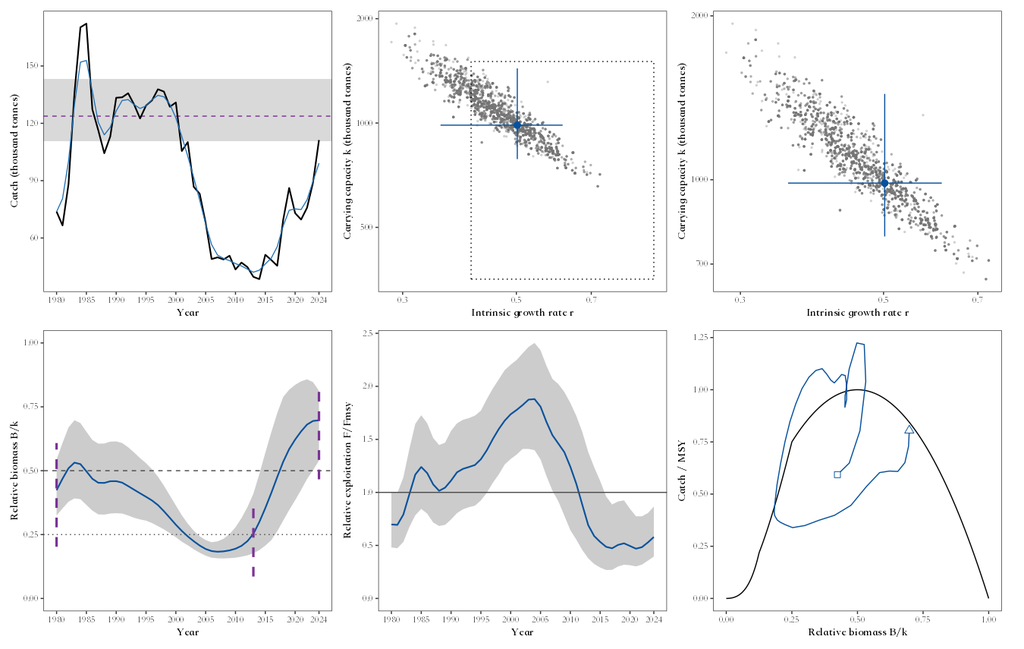

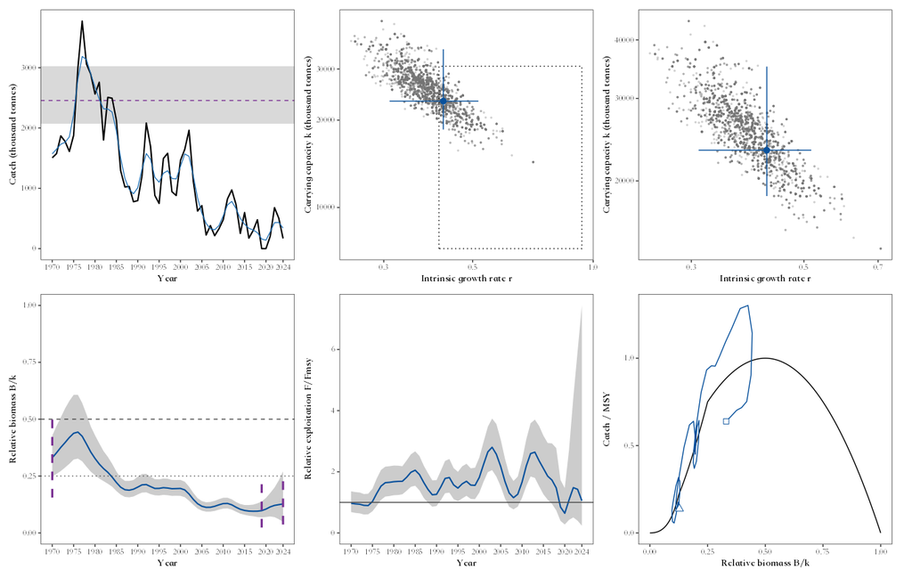

Management charts:

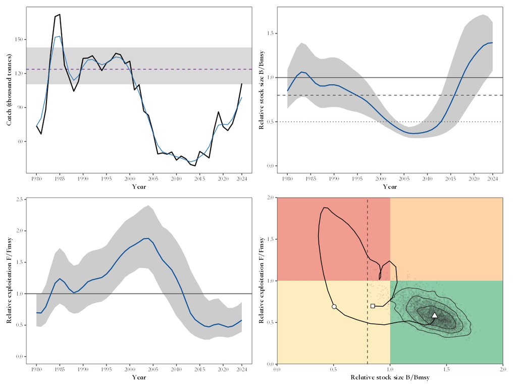

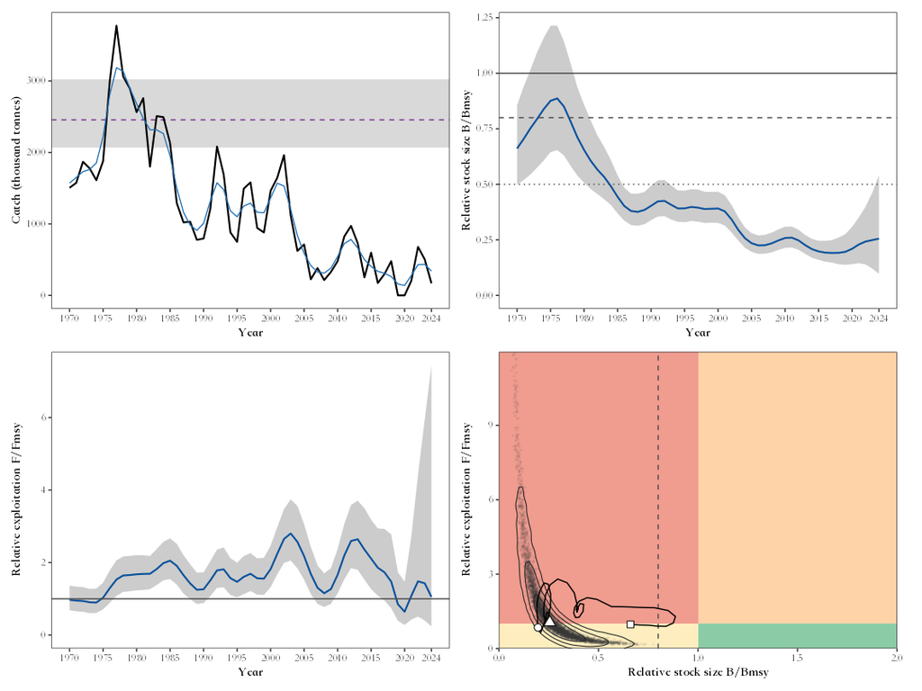

Kobe plots with `annotations = TRUE`:

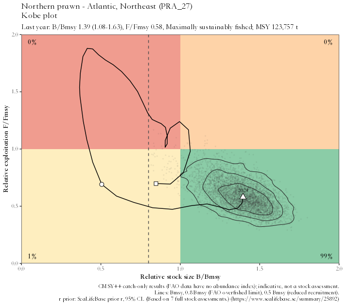

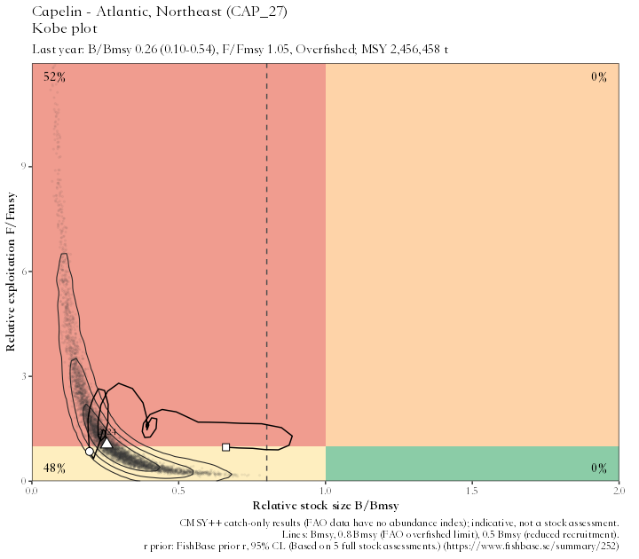

Prior and posterior distributions; the smaller the PPVR, the more the data added to the prior:

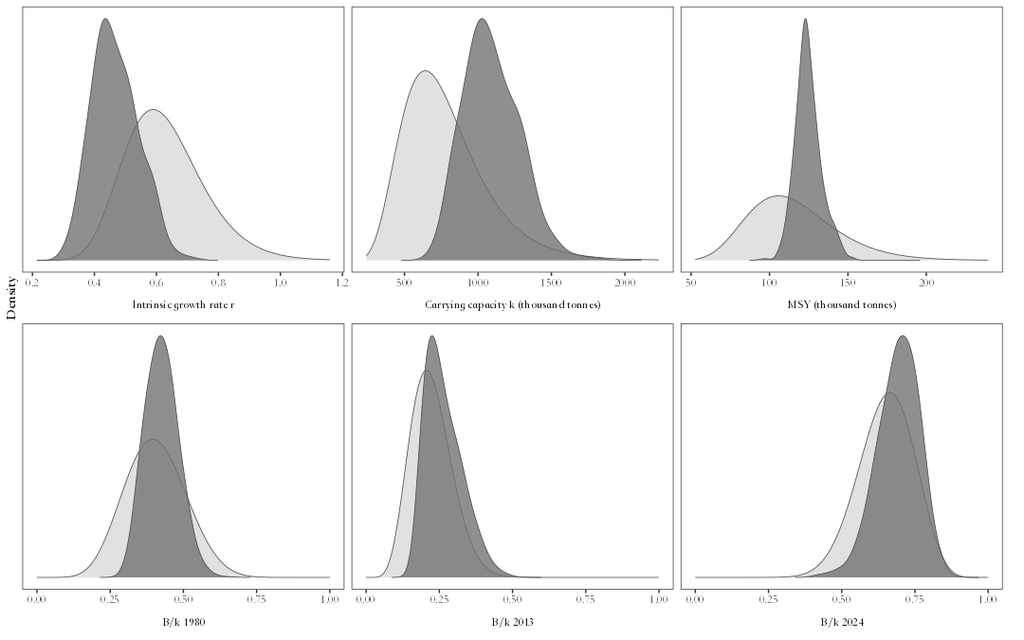

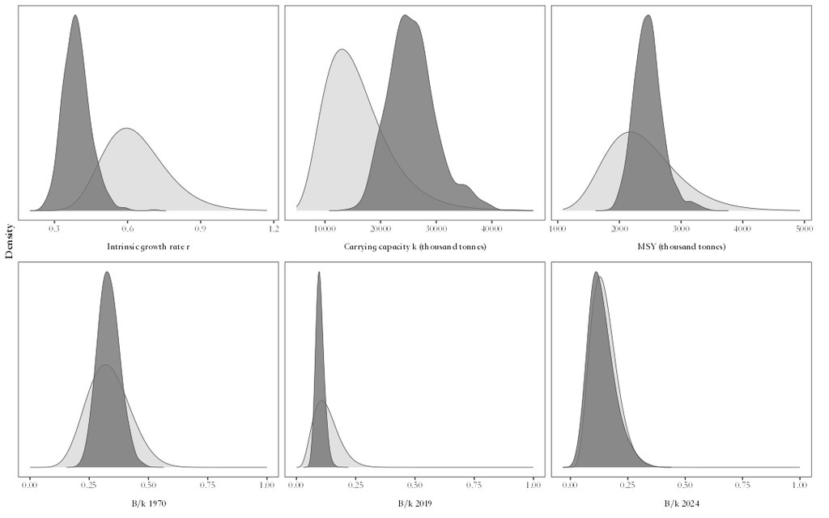

Retrospective analyses:

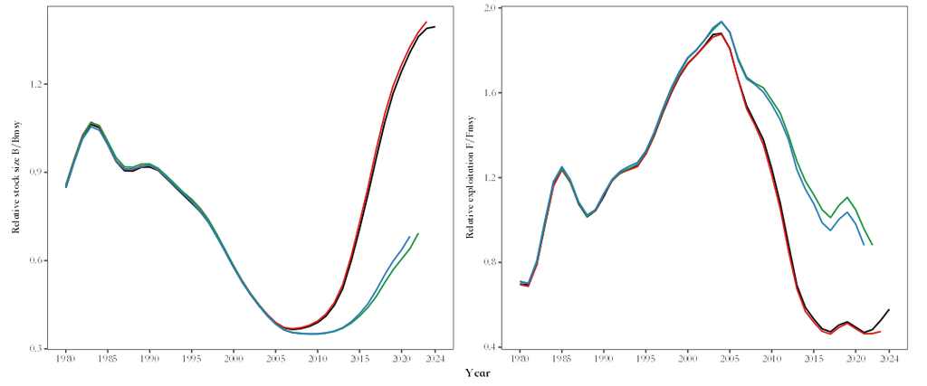

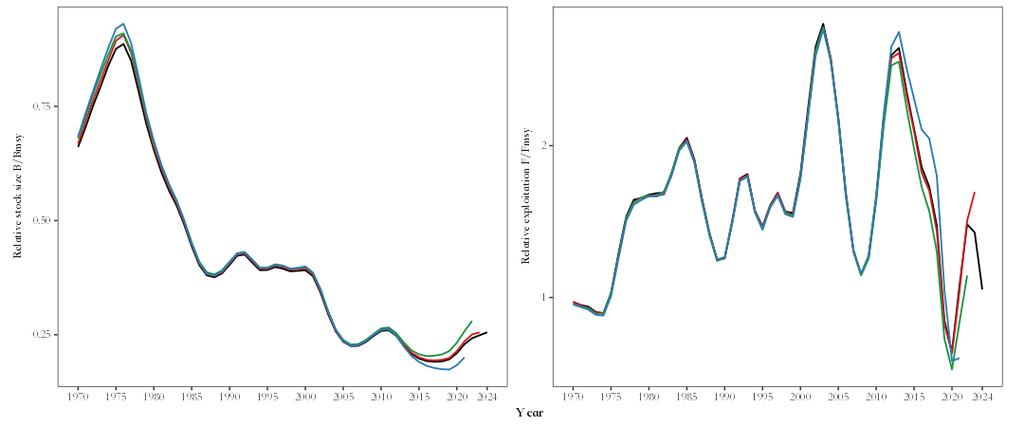

Summaries of the 30 stocks of area 27 (`annotations = "legend"`):

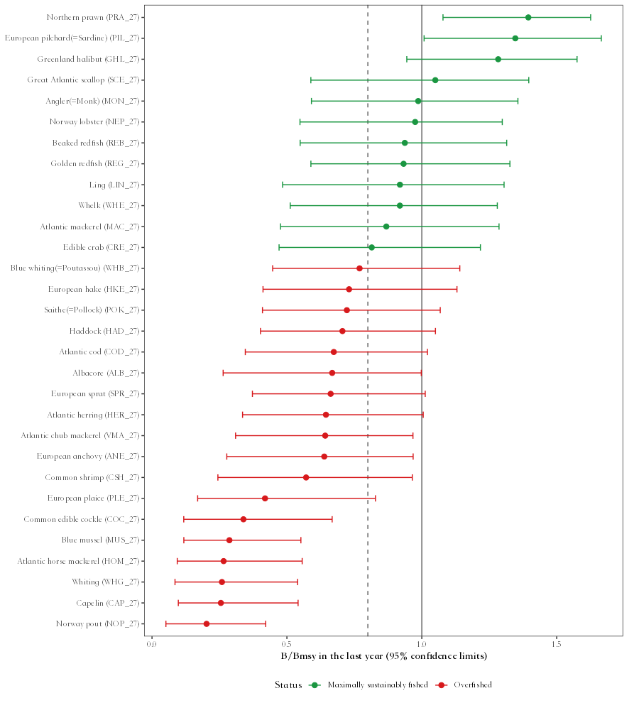

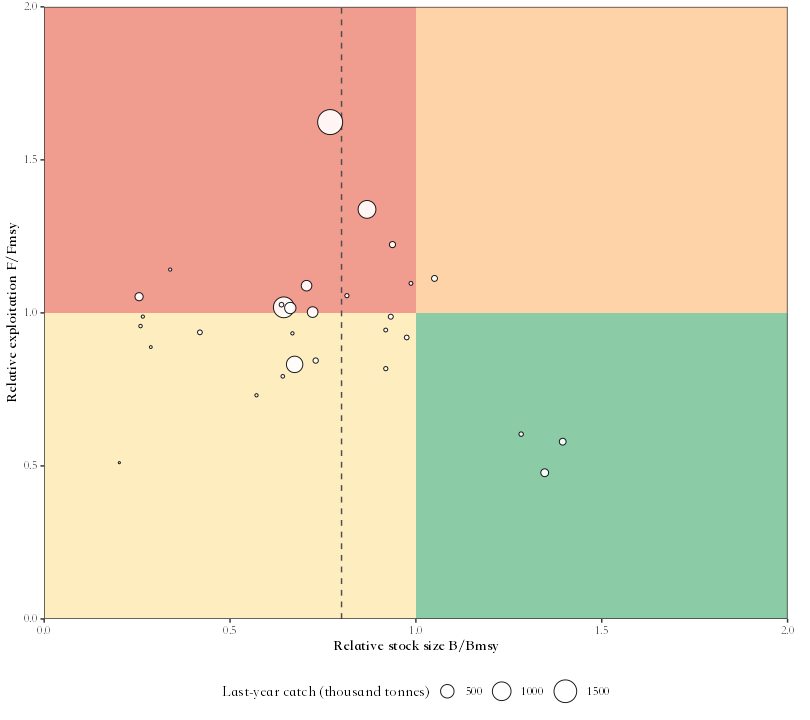

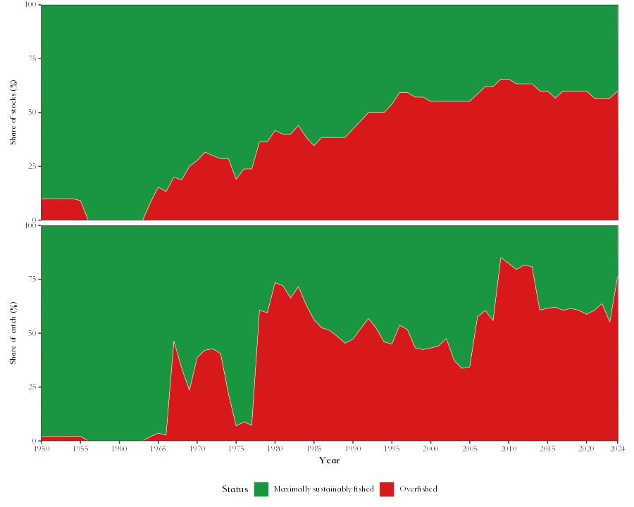

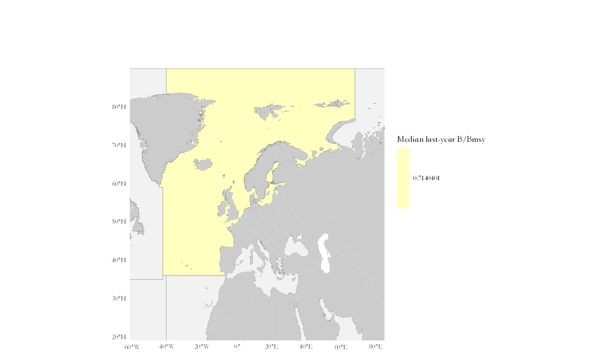

## 🔁 MCMC: settings and convergence

```r
mcmc <- cmsy_mcmc(result)
mcmc$settings        # chains, iterations, burn-in, thinning and draws kept of each stock
mcmc$diagnostics     # posterior summary, Rhat and effective sample size of each parameter
cmsy_mcmc(result, colors = c("grey30", "#D7191C"))   # other colours for the chains
```

CMSY++ samples the posterior with JAGS by Markov chain Monte Carlo (MCMC). `cmsy_run()` keeps the draws of each chain of r, k, B/k, B/Bmsy and F/Fmsy (MSY is computed from r and k, as in `CMSY++16.R`), and `cmsy_mcmc()` checks them. **Rhat** (Gelman and Rubin 1992) compares the variance between chains with the variance within them; at most 1.1 the chains are taken as converged (Gelman et al. 2013). The **effective sample size** (`n_eff`, computed with coda; Plummer et al. 2006) is the number of independent draws that the autocorrelated draws are worth; below 400 (Vehtari et al. 2021) the 95% limits are imprecise. Stocks that did not converge and stocks with too few effective draws are reported apart. The chart shows the draws of each chain in the order they were kept (trace: chains that mix well overlap with no trend) and their densities (which should agree).

The two example stocks, with the settings of `CMSY++16.R` (2 chains of 60,000 iterations, the first 30,000 discarded as burn-in, one draw in 10 kept) and with 4 chains of 300,000 iterations (150,000 burn-in, one draw in 50 kept; columns `_long`):

```r
mc <- rbind(cbind(stock = "PRA_27", read.csv(file.path(fig_dir, "green_mcmc.csv"), check.names = FALSE)),
            cbind(stock = "CAP_27", read.csv(file.path(fig_dir, "overfished_mcmc.csv"), check.names = FALSE)))
mc <- mc[mc$parameter != "deviance", ]
rk <- mc[mc$parameter %in% c("r", "k", "msy"), ]
shown <- mc[, c("stock", "label", "median", "rhat", "n_eff", "median_long", "rhat_long", "n_eff_long")]
shown[c("median", "median_long")] <- lapply(shown[c("median", "median_long")], function(x)
  vapply(signif(x, 3), format, character(1), big.mark = ",", scientific = FALSE))
shown[c("rhat", "rhat_long")] <- lapply(shown[c("rhat", "rhat_long")], sprintf, fmt = "%.3f")
shown[c("n_eff", "n_eff_long")] <- lapply(shown[c("n_eff", "n_eff_long")], function(x) format(round(x), big.mark = ","))
show_table(data.frame(shown, row.names = NULL), n = 20, digits = 3)
```

| stock | label | median | rhat | n_eff | median_long | rhat_long | n_eff_long |
| --- | --- | --- | --- | --- | --- | --- | --- |
| PRA_27 | Intrinsic growth rate r | 0.459 | 1.003 | 183 | 0.468 | 1.001 | 1,471 |
| PRA_27 | Carrying capacity k (t) | 1,070,000 | 1.002 | 164 | 1,050,000 | 1.001 | 1,254 |
| PRA_27 | MSY (t) | 124,000 | 1.000 | 151 | 123,000 | 1.001 | 1,451 |
| PRA_27 | B/k in the first year | 0.424 | 1.003 | 262 | 0.432 | 1.000 | 1,929 |
| PRA_27 | B/k in the last year | 0.697 | 1.008 | 230 | 0.693 | 1.000 | 1,528 |
| PRA_27 | B/Bmsy in the last year | 1.39 | 1.008 | 230 | 1.39 | 1.000 | 1,528 |
| PRA_27 | F/Fmsy in the last year | 0.579 | 1.001 | 492 | 0.588 | 1.000 | 2,811 |
| CAP_27 | Intrinsic growth rate r | 0.386 | 1.055 | 256 | 0.383 | 1.001 | 2,105 |
| CAP_27 | Carrying capacity k (t) | 25,400,000 | 1.094 | 124 | 25,800,000 | 1.001 | 703 |
| CAP_27 | MSY (t) | 2,460,000 | 1.034 | 80 | 2,480,000 | 1.000 | 524 |
| CAP_27 | B/k in the first year | 0.331 | 1.034 | 216 | 0.326 | 1.000 | 867 |
| CAP_27 | B/k in the last year | 0.128 | 1.018 | 142 | 0.13 | 1.007 | 1,437 |
| CAP_27 | B/Bmsy in the last year | 0.255 | 1.018 | 142 | 0.259 | 1.007 | 1,437 |
| CAP_27 | F/Fmsy in the last year | 1.05 | 1.082 | 262 | 1.03 | 1.022 | 1,926 |

With the default settings the chains converged (Rhat at most 1.09), but the effective sample size of r, k and MSY was only 80 to 256: successive draws of r and k are strongly correlated. With the longer chains it rose to 524 to 2105, while the medians hardly changed (last-year B/Bmsy of northern prawn 1.395 and 1.386, of capelin 0.255 and 0.259), and the runs took about five times as long (4 chains instead of 2 run side by side, but each five times longer). For results to report, run CMSY++ with longer and more chains and check them:

```r
result <- cmsy_run(input, seed = 1, auto_start = TRUE,
                   settings = list(n.chains = 4, n.iter = 300000, n.burnin = 150000, n.thin = 50))
cmsy_mcmc(result)
```

Trace and density of each chain, northern prawn and capelin (default settings):

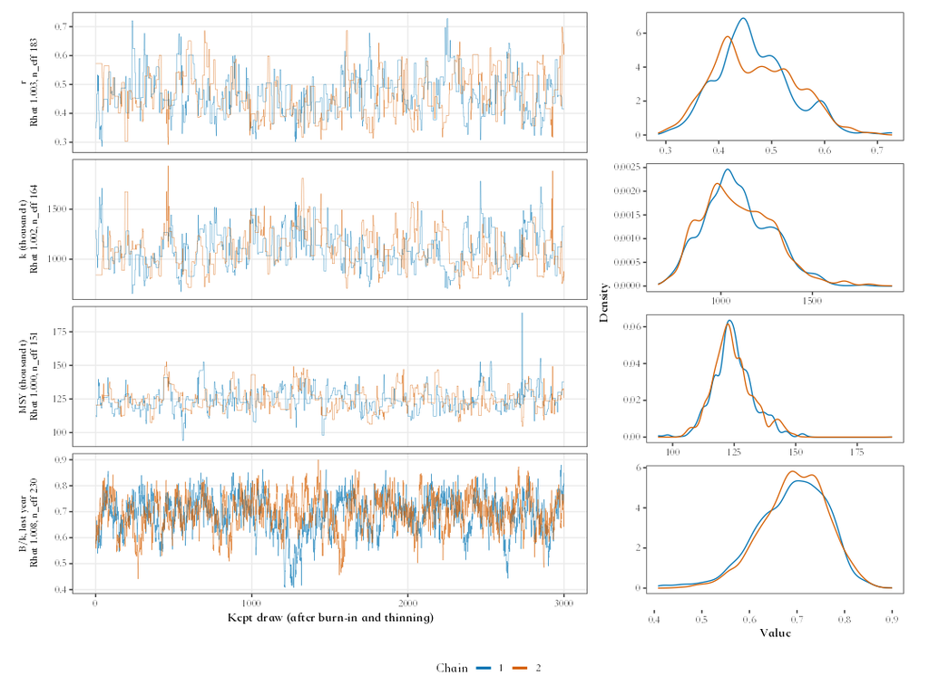

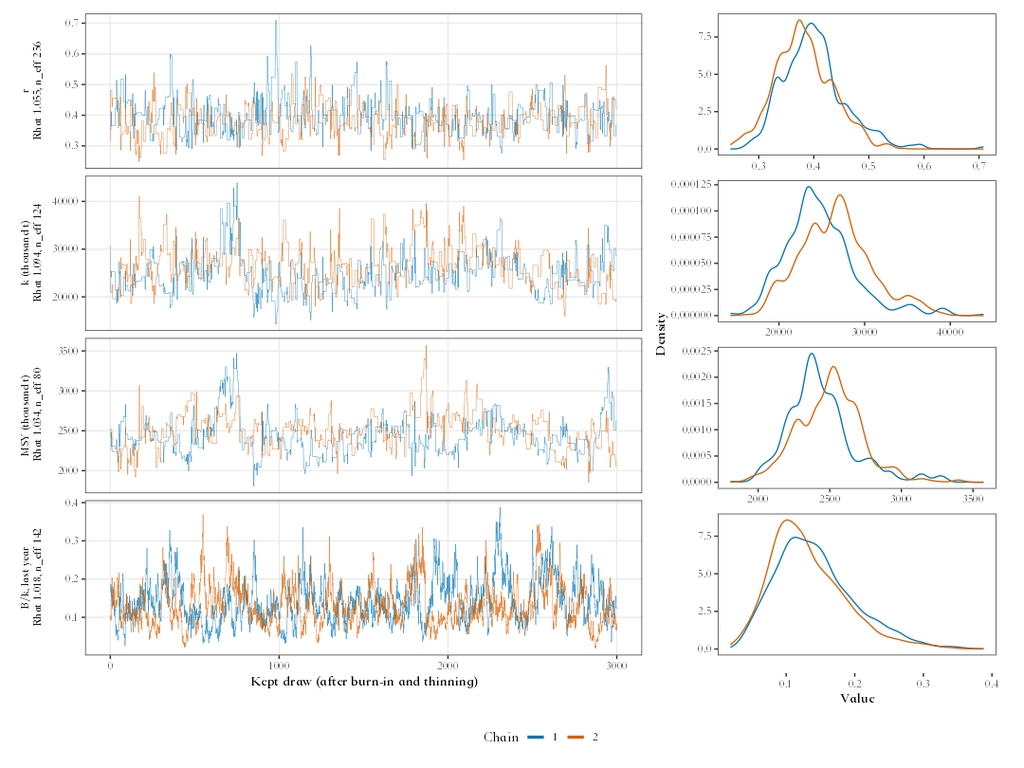

| Argument | Meaning | Default |
| --- | --- | --- |
| `result` | The result of `cmsy_run()` or `cmsy_area()` | required |
| `stocks` | Stocks to check (see Common arguments) | `NULL`: all stocks that ran |
| `rhat_max` | Largest Rhat taken as converged | `1.1` |
| `n_eff_min` | Smallest effective sample size (all chains together) taken as enough | `400` |
| `plot`, `table` | Save the chart `figures/png/cmsy/<stock>/mcmc.png` and the tables `tables/cmsy/mcmc_settings.csv` and `mcmc_diagnostics.csv` | `TRUE` |
| `colors` | Colours of the chains: `NULL` (Okabe-Ito colours), a palette name (e.g. `"npg"`, `"Set1"`, `"viridis"`) or one colour per chain | `NULL` |
| `lang`, `pptx`, `silent` | See Common arguments |  |

The same chart is the `"mcmc"` chart of `cmsy_plot()` (colours with `mcmc_colors`). Results of earlier versions of the package have no draws: run CMSY++ again to check them. Converged chains do not mean that the priors or the model fit the stock.

## 🔮 Step 7: projections under fishing scenarios

```r
projection <- cmsy_forecast(result, catch = 100000)
```

`CMSY++16.R` has no projection, so `cmsy_forecast()` projects with the CMSY++ model itself (Schaefer surplus production with productivity declining below 0.25 k), from the posterior draws of r, k and last-year B/k of the same MCMC iterations, with lognormal process error of standard deviation `sigma` (0.1 by default, the value `CMSY++16.R` gives to its setting `sigmaR`, which the model itself does not use: it estimates its process error). As in CMSY++, the biomass of a year is the biomass before that year’s catch, F is the catch divided by that biomass, and F/Fmsy uses an Fmsy reduced linearly below half of Bmsy. The last year of the data keeps its catch; from the first projected year on, the catch of an F scenario is the scenario F times the biomass of the same year, so F/Fmsy is the scenario value. The default scenarios are 0.5, 0.6, 0.8 and 0.95 Fmsy (as in Froese et al. 2018) and the last-year fishing mortality; constant catches can be added (`catch`). Stocks whose data end in different years are each projected from their own last year to the same final year.

| Argument | Meaning | Default |
| --- | --- | --- |
| `result` | The result of `cmsy_run()` | required |
| `stocks` | Stocks to project (see Common arguments) | `NULL`: all stocks that ran |
| `years` | Number of years to project after the latest last year of the stocks | `10` |
| `f` | Fishing mortality scenarios as multiples of Fmsy | `c(0.5, 0.6, 0.8, 0.95)` |
| `status_quo` | Also project the last-year fishing mortality | `TRUE` |
| `catch` | Constant catches to project (tonnes per year) | `NULL` |
| `sigma` | Standard deviation of the lognormal process error | `0.1` |
| `seed` | Random seed | `NULL` |
| `plot` | Save the charts `figures/png/cmsy/<stock>/forecast.png` and `figures/png/cmsy/summary/forecast_share.png` | `TRUE` |
| `table` | Save `tables/cmsy/forecast.csv` and `forecast_share.csv` | `TRUE` |
| `lang`, `annotations`, `pptx`, `silent` | See Common arguments |  |

It returns `projection` (by stock, scenario and year: median B/Bmsy, F/Fmsy and catch with 95% limits, and the probability that B is at least Bmsy) and `share` (by scenario and year: share of stocks at or above Bmsy, with 95% limits, and the number of stocks `n_stocks`; from the latest last year of the stocks on).

With constant catches near the MSY of each stock (100,000 t for northern prawn, 2,000,000 t for capelin) and the F scenarios:

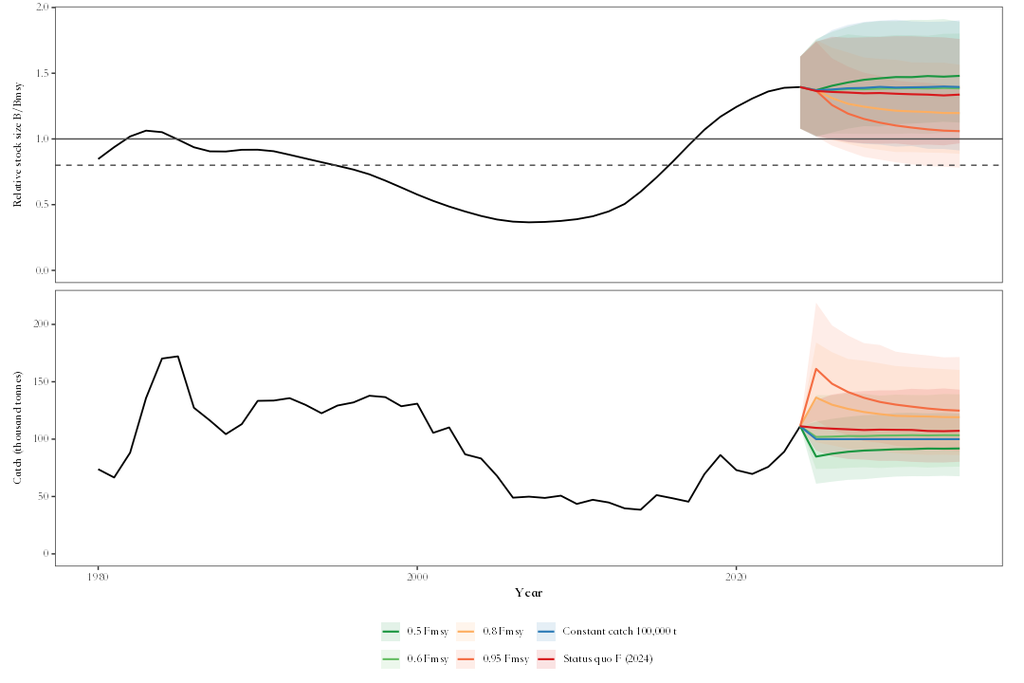

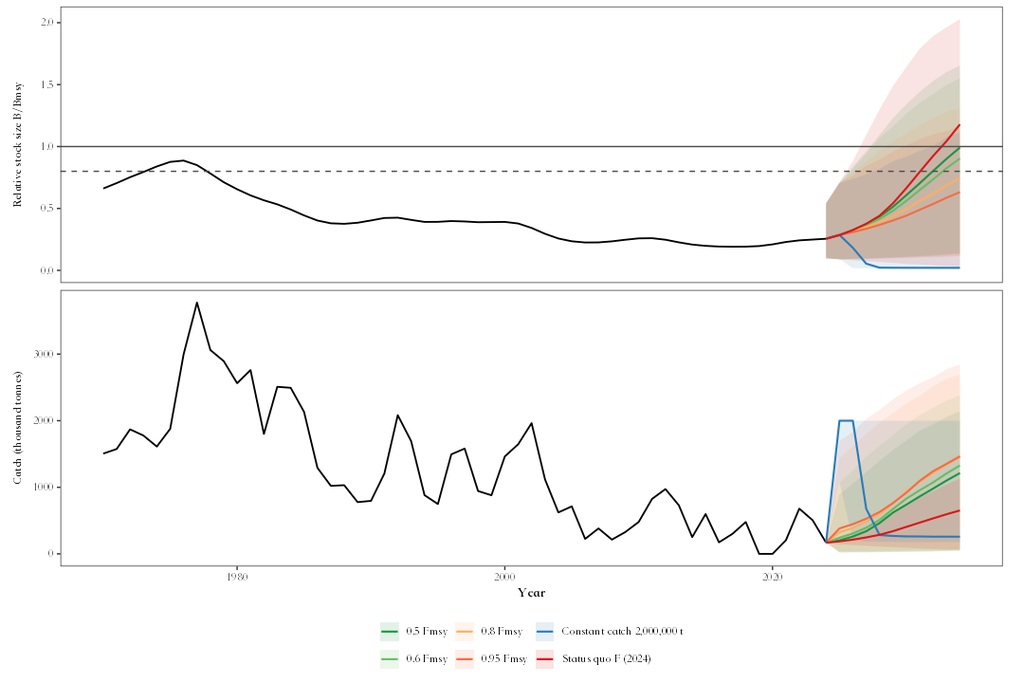

## 🔍 Step 8: compare runs or other assessments

```r
result_1950 <- cmsy_run(input, stocks = "PRA_27", seed = 1)        # starting in 1950
cmsy_compare(`1950` = result_1950, `CMSY++` = result, stocks = "PRA_27")
```

`cmsy_compare()` draws several runs (e.g. different start years or priors, a sensitivity analysis) and other estimates (`external`, e.g. B/Bmsy from ICES, JABBA or a paper) together and lists their last-year values. The start year matters. Started in 1950, northern prawn has a last-year B/Bmsy of 0.82, below Bmsy; started in 1980 as CMSY++ suggests, 1.39, above it. Capelin is overfished from either start year (0.25 from 1950, 0.26 from 1970):

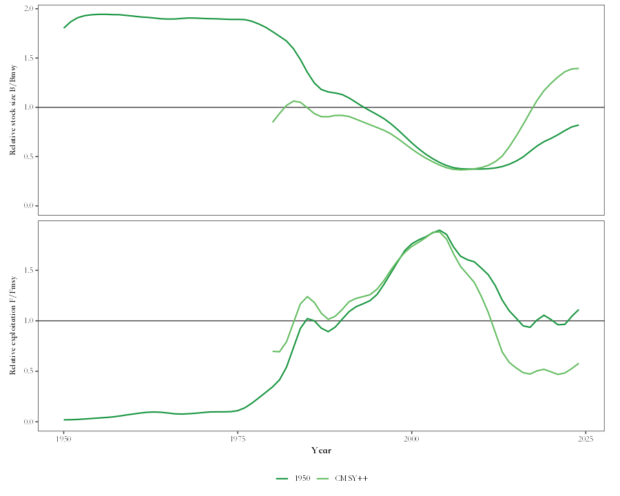

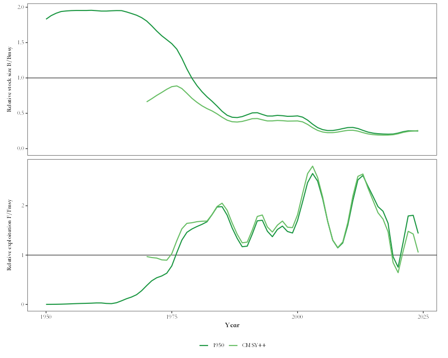

| Argument | Meaning | Default |
| --- | --- | --- |
| `...` | Results of `cmsy_run()`, named or not (e.g. `default = run1, start_1980 = run2`) |  |
| `stocks` | Stocks to draw (see Common arguments) | `NULL`: all stocks that ran |
| `external` | Data frame of other estimates, with columns `Stock`, `Year`, `B_Bmsy` (optionally `F_Fmsy`) and `source` (the name shown in the legend) | `NULL` |
| `lang`, `annotations`, `pptx`, `silent` | See Common arguments |  |

The charts are saved as `figures/png/cmsy/compare/<stock>.png`; the function returns `last_year` (one row per stock and run) and `plots`.

## 📋 Step 9: tables for reports

```r
tables <- cmsy_tables(result)
```

`cmsy_tables()` makes the two tables of CMSY papers, the priors table and the results table shown in Step 5, rounded, with ranges as “low-high” and column names in the chosen language, saved as `tables/cmsy/cmsy_priors_table.csv` and `cmsy_results_table.csv`. The results give the status in the two classes of FAO (2026) and in the five classes of Palomares et al. (2018).

| Argument | Meaning | Default |
| --- | --- | --- |
| `result` | The result of `cmsy_run()` | required |
| `stocks` | Stocks in the tables (see Common arguments) | `NULL`: all stocks that ran |
| `table`, `lang`, `silent` | See Common arguments |  |

## ⚙️ The settings of CMSY++

CMSY++ has a set of general settings, such as the catch observation error `CV.C` and the number of MCMC chains and iterations. Two of them, `sigmaR` and `ni`, are set in `CMSY++16.R` but not used by its code (the model estimates its process error with the prior `itau2 ~ dgamma(4, 0.01)`): they are listed as “not used” and cannot be changed, so that a run is not mistaken for a sensitivity analysis of the process error. `cmsy_run()` keeps the CMSY++ values unless they are changed; `cmsy_defaults()` lists each one with its CMSY++ default, the value used and what it does:

```r
show_table(cmsy_defaults()[, c("setting", "cmsy_default", "applies_to", "description")], n = 30)
```

| setting | cmsy_default | applies_to | description |
| --- | --- | --- | --- |
| CV.C | 0.15 | all | Coefficient of variation of the catch (observation error) |
| CV.cpue | 0.2 | BSM | Minimum realistic coefficient of variation of CPUE |
| sigmaR | 0.1 | not used | Not used by CMSY++16.R: the code sets it (sigR <- sigmaR) but never uses it; the model estimates its process error with the prior itau2 ~ dgamma(4, 0.01). It cannot be changed |
| cor.log.rk | -0.76 | charts | Correlation of log r and log k, used only in charts |
| rk.cor.beta | 2.52, 3.37 | all | Beta prior of the r-k correlation plus 1 |
| nbk | 3 | BSM | Number of B/k priors used by BSM: 1 (first year), 2 (and intermediate year), 3 (and last year) |
| bt4pr | FALSE | BSM | Use the abundance data to set the B/k priors |
| ct_MSY.lim | 1.21 | all | Ratio of catch to the MSY prior above which the B/k prior is kept constant |
| q.biomass.pr | 0.9, 1.1 | BSM | Prior range of q when the abundance data are biomass |
| n | 5000 | charts | Number of points of the r-k cloud in the analysis chart |
| ni | 3 | not used | Not used by CMSY++16.R: the code sets it but never uses it. It cannot be changed |
| nab | 3 | BSM | Minimum number of years with abundance data to run BSM |
| bw | 3 | all | Bandwidth of ksmooth() for smoothing the catch |
| e.creep.line | TRUE | charts | Show the CPUE not corrected for effort creep in the biomass chart |
| select.yr | NA | output | Year for which B, F, B/Bmsy and F/Fmsy are also reported (NA: none) |
| n.chains | 2 | all | Number of MCMC chains (JAGS) |
| n.iter | 60000 | all | Number of MCMC iterations per chain (JAGS) |
| n.burnin | 30000 | all | Number of burn-in iterations (JAGS) |
| n.thin | 10 | all | Thinning of the MCMC chains (JAGS) |

Settings marked “BSM” only matter with abundance data (CPUE or biomass); with FAO catch data only those marked “all” affect the results. To change some, give only those in `settings`; the others keep their CMSY++ values, and every value is checked (name, range, enough MCMC draws):

```r
cmsy_defaults(list(CV.C = 0.2, n.iter = 100000, n.burnin = 50000))[c(1, 17, 18), c("setting", "cmsy_default", "used", "changed")]
```

```
#>     setting cmsy_default   used changed
#> 1      CV.C         0.15    0.2    TRUE
#> 17   n.iter        60000 100000    TRUE
#> 18 n.burnin        30000  50000    TRUE
```

```r
result <- cmsy_run(input, stocks = "PRA_27", seed = 1, auto_start = TRUE,
                   settings = list(CV.C = 0.2, n.iter = 100000, n.burnin = 50000))
result$settings[result$settings$changed, ]          # the changed settings
```

| Argument | Meaning | Default |
| --- | --- | --- |
| `settings` | Named list of changed settings, e.g. `list(CV.C = 0.2)`, shown next to the defaults and checked | `list()` |
| `lang` | Language of the `description` column: `"en"`, `"zh"` or `"both"` | `NULL`: the language of `fao_settings()` |

The settings used are saved in `settings_used.csv` of the run folder and recorded in `result$settings` and `result$sources`. The chart and output switches of CMSY++ (`mgraphs`, `kobe.plot`, `retros`, …) are set by the `plots` argument of `cmsy_run()`, not in `settings`.

## 🖥️ Windows, macOS and Linux

The same code runs on all three systems: `cmsy_system()` detects the system and makes the changes it needs (on macOS, no `windows()` and no `antialias = "cleartype"`; see Step 1), and the JAGS installer is chosen for the system and R version. Each change to the CMSY code is checked by the GitHub Actions workflow “CMSY-cross-platform” on Windows, macOS and Linux: it downloads and installs the matching JAGS with `cmsy_download_jags()`, runs CMSY++ for real, runs all CMSY tests and keeps the output of each system.

Results of the check in October 2026, made on two stocks of area 34, the example area of this article at the time (all 170 tests pass for each combination; same seed; `cmsy_area()` on bigeye grunt GRB_34 and sardine PIL_34):

| System | R | JAGS | rjags | GRB_34 B/Bmsy | GRB_34 F/Fmsy | PIL_34 B/Bmsy | PIL_34 F/Fmsy |
| --- | --- | --- | --- | --- | --- | --- | --- |
| Windows | 4.6.1 | 4.3.2 | 4-17 | 1.422 | 0.639 | 0.706 | 1.391 |
| Windows | 4.4.3 | 4.3.1 | 4-17 | 1.422 | 0.639 | 0.706 | 1.391 |
| Windows | 4.3.3 | 4.3.1 | 4-17 | 1.422 | 0.639 | 0.706 | 1.391 |
| Windows | 4.2.3 | 4.3.1 | 4-17 | 1.422 | 0.639 | 0.706 | 1.391 |
| macOS (Apple silicon) | 4.6.1 | 4.3.2 | 4-17 | 1.422 | 0.639 | 0.706 | 1.391 |
| Ubuntu | 4.6.1 | 4.3.2 (apt) | 4-17 | 1.422 | 0.639 | 0.706 | 1.391 |
| macOS (Apple silicon) | 4.2.3 | 4.3.1 | 4-15 | 1.366 | 0.663 | 0.745 | 1.306 |
| Windows | 4.6.1 | 5.0.0 | 5-3 | 1.392 | 0.672 | 0.740 | 1.317 |
| macOS (Apple silicon) | 4.6.1 | 5.0.0 | 5-3 | 1.392 | 0.672 | 0.740 | 1.317 |

With the same JAGS 4.3.x and rjags 4-17, the results are identical on all three systems. JAGS 5 or an older rjags draws different MCMC samples, so the numbers differ slightly (B/Bmsy of GRB_34 from 1.37 to 1.42, all inside its 95% interval 1.08–1.65), but the status of both stocks is the same: GRB_34 maximally sustainably fished, PIL_34 overfished. To repeat a result exactly, use the same JAGS and rjags versions; they are recorded in `result$sources` and `tables/sources.csv`.

## ⏱️ Progress bars and silent

`cmsy_run()`, `cmsy_plot()`, `cmsy_forecast()` and `cmsy_area()` show progress bars such as

```
CMSY++ [==================            ] 18/30 ( 60%) 00:51 elapsed, 00:34 left COD_27
```

All CMSY functions that print have a `silent` argument: with `silent = TRUE` they print no progress bars or messages (`cmsy_setup()` still asks before installing). `fao_settings(silent = TRUE)` sets the session default.

## 📝 In the Word report

`fao_report()` assesses the main species of the area with CMSY++ when `cmsy = TRUE` (see 📝 Assessment report: Word, LaTeX and PDF), and adds a part on the assessment with the results of every species and appendix tables of the reference points, the priors and their sources. It runs `cmsy_area()` on the `top_n` main species of the report (10 by default), without projections. The settings of `cmsy_area()` and `cmsy_input()` are given with the prefix `cmsy_`, e.g. `cmsy_top = 5`, `cmsy_default_resilience = "Medium"` or `cmsy_settings = list(n.iter = 100000)`. All CMSY++ results (runs, charts and tables) are kept in the folder `cmsy/` next to the report, with `cmsy_result.rds`, so the report can be written again without running CMSY++: `cmsy = readRDS("cmsy/<area>/cmsy_result.rds")`, with the path from the working directory (by default `reports/cmsy/<area>/cmsy_result.rds`). The result of an earlier `cmsy_area()` run can be given in the same way.

```r
report <- fao_report(27, cmsy = TRUE, cmsy_top = 5)
report$cmsy_reference_points                  # r, k, MSY, B/Bmsy, ... with 95% limits
fao_report(27, cmsy = readRDS("reports/cmsy/Atlantic__Northeast/cmsy_result.rds"))
```

## 📖 References

Boettiger, C., Lang, D.T. and Wainwright, P.C. (2012). rfishbase: exploring, manipulating and visualizing FishBase data from R. *Journal of Fish Biology* 81(6): 2030–2039. [doi:10.1111/j.1095-8649.2012.03464.x](https://doi.org/10.1111/j.1095-8649.2012.03464.x). Source code: https://github.com/ropensci/rfishbase

FAO (2026). *Global Capture Production 1950–2024*, release 2026.1.0. In: Fisheries and Aquaculture. Rome: FAO. https://www.fao.org/fishery/collection/capture/en. Licence: CC BY 4.0. Release file: https://www.fao.org/fishery/static/Data/Capture_2026.1.0.zip

FAO (2026). *The State of World Fisheries and Aquaculture 2026 – Blue Transformation: turning vision into impact*. Rome: FAO. [doi:10.4060/cd8357en](https://doi.org/10.4060/cd8357en). Section “The status of fishery resources”, Box 1.3 (assessment tiers and status classes): https://openknowledge.fao.org/server/api/core/bitstreams/09d03e2f-7097-4d59-bf94-db65e95f44fd/content/sofia-2026/the-status-fishery-resources.html

Free, C.M., Jensen, O.P., Anderson, S.C., Gutierrez, N.L., Kleisner, K.M., Longo, C., Minto, C., Osio, G.C. and Walsh, J.C. (2020). Blood from a stone: performance of catch-only methods in estimating stock biomass status. *Fisheries Research* 223: 105452. [doi:10.1016/j.fishres.2019.105452](https://doi.org/10.1016/j.fishres.2019.105452)

Froese, R., Demirel, N., Coro, G., Kleisner, K.M. and Winker, H. (2017). Estimating fisheries reference points from catch and resilience. *Fish and Fisheries* 18: 506–526. [doi:10.1111/faf.12190](https://doi.org/10.1111/faf.12190)

Froese, R., Demirel, N., Coro, G. and Winker, H. (2021). *User Guide for CMSY++*. GEOMAR, Germany, 17 pp. https://oceanrep.geomar.de/id/eprint/52147/ (bundled with the package: `system.file("cmsy", "CMSYUserGuideMarch2021.pdf", package = "faofishingreport")`)

Froese, R. and Pauly, D. (Eds.) (2026). FishBase. World Wide Web electronic publication. Version (06/2026). https://www.fishbase.se

Froese, R., Winker, H., Coro, G., Demirel, N., Tsikliras, A.C., Dimarchopoulou, D., Scarcella, G., Quaas, M. and Matz-Lück, N. (2018). Status and rebuilding of European fisheries. *Marine Policy* 93: 159–170. [doi:10.1016/j.marpol.2018.04.018](https://doi.org/10.1016/j.marpol.2018.04.018)

Froese, R., Winker, H., Coro, G., Palomares, M.L.D., Tsikliras, A.C., Dimarchopoulou, D., Touloumis, K., Demirel, N., Vianna, G.M.S., Scarcella, G., Schijns, R., Liang, C. and Pauly, D. (2023). New developments in the analysis of catch time series as the basis for fish stock assessments: the CMSY++ method. *Acta Ichthyologica et Piscatoria* 53: 173–189. [doi:10.3897/aiep.53.105910](https://doi.org/10.3897/aiep.53.105910)

Gelman, A., Carlin, J.B., Stern, H.S., Dunson, D.B., Vehtari, A. and Rubin, D.B. (2013). *Bayesian Data Analysis*, 3rd edition. Boca Raton: CRC Press. [doi:10.1201/b16018](https://doi.org/10.1201/b16018)

Gelman, A. and Rubin, D.B. (1992). Inference from iterative simulation using multiple sequences. *Statistical Science* 7(4): 457–472. [doi:10.1214/ss/1177011136](https://doi.org/10.1214/ss/1177011136)

Kell, L.T., Sharma, R. and Winker, H. (2022). Artefact and artifice: evaluation of the skill of catch-only methods for classifying stock status. *Frontiers in Marine Science* 9: 762203. [doi:10.3389/fmars.2022.762203](https://doi.org/10.3389/fmars.2022.762203)

Mohn, R. (1999). The retrospective problem in sequential population analysis: an investigation using cod fishery and simulated data. *ICES Journal of Marine Science* 56: 473–488. [doi:10.1006/jmsc.1999.0481](https://doi.org/10.1006/jmsc.1999.0481)

Ovando, D., Hilborn, R., Monnahan, C., Rudd, M., Sharma, R., Thorson, J.T., Rousseau, Y. and Ye, Y. (2021). Improving estimates of the state of global fisheries depends on better data. *Fish and Fisheries* 22: 1377–1391. [doi:10.1111/faf.12593](https://doi.org/10.1111/faf.12593)

Palomares, M.L.D., Froese, R., Derrick, B., Nöel, S.-L., Tsui, G., Woroniak, J. and Pauly, D. (2018). *A preliminary global assessment of the status of exploited marine fish and invertebrate populations*. A report prepared by the Sea Around Us for OCEANA. University of British Columbia and GEOMAR. https://www.fishbase.de/rfroese/OceanaFinalReport_V7a.pdf

Palomares, M.L.D. and Pauly, D. (Eds.) (2026). SeaLifeBase. World Wide Web electronic publication. Version (06/2026). https://www.sealifebase.se

Plummer, M. (2003). JAGS: a program for analysis of Bayesian graphical models using Gibbs sampling. In: *Proceedings of the 3rd International Workshop on Distributed Statistical Computing (DSC 2003)*, Vienna, 1–10. https://www.r-project.org/conferences/DSC-2003/Proceedings/Plummer.pdf; JAGS: https://mcmc-jags.sourceforge.io/

Plummer, M., Best, N., Cowles, K. and Vines, K. (2006). CODA: convergence diagnosis and output analysis for MCMC. *R News* 6(1): 7–11. https://journal.r-project.org/articles/RN-2006-002/

Plummer, M. (2025). rjags: Bayesian Graphical Models using MCMC. R package version 4-17. [doi:10.32614/CRAN.package.rjags](https://doi.org/10.32614/CRAN.package.rjags)

Su, Y. and Yajima, M. (2024). R2jags: Using R to Run ‘JAGS’. R package version 0.8-9. [doi:10.32614/CRAN.package.R2jags](https://doi.org/10.32614/CRAN.package.R2jags)

Vehtari, A., Gelman, A., Simpson, D., Carpenter, B. and Bürkner, P.-C. (2021). Rank-normalization, folding, and localization: an improved Rhat for assessing convergence of MCMC. *Bayesian Analysis* 16(2): 667–718. [doi:10.1214/20-BA1221](https://doi.org/10.1214/20-BA1221)